# 手把手R語言一日初階實作

許sir

2019/9/5

### 教學大綱

#### [PART 1]. R的基本語法

#### [PART 2]. Data ETL

#### [PART 3]. 探索性資料分析及資料視覺化

#### [PART 4]. 專案一: 婚姻品質是否會導致婚外情?

#### [PART 5]. 專案二:我想買房子(房屋實價登錄資料集)

[figure not shown]

### [.設定所需的函式庫(libraries)以及載入資料]

```r
#if(!require(installr)) { install.packages("installr"); require(installr)} #load / install+load installr

#install.pandoc()
```

```r
rm()  #清除所有物件
setwd("C:/My-Coding-zone/R/R-TKU") #設定工作區
getwd()  #查詢工作區
```

## [PART 1]. R的基本語法

### 1-1. Rmarkdown 文件的常用語法

### 1-1-1. 字型大小：

### R語言工作坊

#### R語言工作坊

##### R語言工作坊

###### R語言工作坊

### 1-1-2. 文句強調：

### *斜體* and **粗體**

### 1-1-3. 條列語句：

### 你覺得寫程式___: - 令人開心 - 覺得沮喪 - 超不爽 - 輕鬆愉快

### 1-1-4. 表格：

| 第一組 | 第二組 | 第三組 | 第四組 | 第五組 |
| --- | --- | --- | --- | --- |
| 樣本1 | 樣本2 | 樣本3 | 樣本4 | 樣本5 |
| 樣本6 | 樣本7 | 樣本8 | 樣本9 | 樣本10 |

### 1-1-5. 上下標：

- 單位：km<sup>2</sup>
- 二氧化碳: CO<sub>2</sub>

### 1-1-6. 分隔線：

### 我們採用內建的iris資料

- 花萼長度(Sepal Length)
- 花萼寬度(Sepal Width)
- 花瓣長度(Petal Length)
- 花瓣寬度(Petal Width)
- 類別(Species)：可分為Setosa，Versicolor和Virginica三個品種。

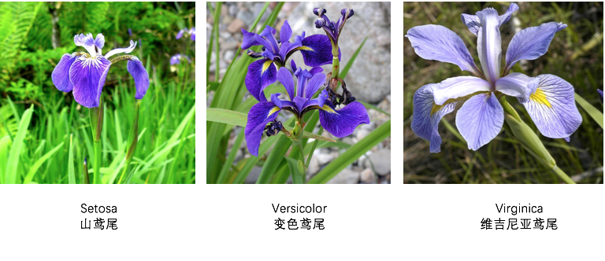

```r
data(iris)
dim(iris) # 查看列數與欄數
```

```
## [1] 150   5
```

```r
#看看IRIS資料集的頭尾
head(iris, 10) #取前10筆資料
```

```
##    Sepal.Length Sepal.Width Petal.Length Petal.Width Species
## 1           5.1         3.5          1.4         0.2  setosa
## 2           4.9         3.0          1.4         0.2  setosa
## 3           4.7         3.2          1.3         0.2  setosa
## 4           4.6         3.1          1.5         0.2  setosa
## 5           5.0         3.6          1.4         0.2  setosa
## 6           5.4         3.9          1.7         0.4  setosa
## 7           4.6         3.4          1.4         0.3  setosa
## 8           5.0         3.4          1.5         0.2  setosa
## 9           4.4         2.9          1.4         0.2  setosa
## 10          4.9         3.1          1.5         0.1  setosa
```

```r
tail(iris,10) #取後10筆資料
```

```
##     Sepal.Length Sepal.Width Petal.Length Petal.Width   Species
## 141          6.7         3.1          5.6         2.4 virginica
## 142          6.9         3.1          5.1         2.3 virginica
## 143          5.8         2.7          5.1         1.9 virginica
## 144          6.8         3.2          5.9         2.3 virginica
## 145          6.7         3.3          5.7         2.5 virginica
## 146          6.7         3.0          5.2         2.3 virginica
## 147          6.3         2.5          5.0         1.9 virginica
## 148          6.5         3.0          5.2         2.0 virginica
## 149          6.2         3.4          5.4         2.3 virginica
## 150          5.9         3.0          5.1         1.8 virginica
```

### 1-2.中央趨勢量數

```r
mean(iris$Sepal.Length)     #「花萼長度」的平均值
```

```
## [1] 5.843333
```

```r
median(iris$Sepal.Length)   #「花萼長度」的中位數
```

```
## [1] 5.8
```

```r
max(iris$Sepal.Length)      #「花萼長度」中的最大值
```

```
## [1] 7.9
```

```r
min(iris$Sepal.Length)      #「花萼長度」中的最小值
```

```
## [1] 4.3
```

```r
sum(iris$Sepal.Length)      #「花萼長度」加總
```

```
## [1] 876.5
```

```r
#類別資料算平均，得到NA不是夢
mean(iris$Species)
```

```
## [1] NA
```

### 1-3.分散趨勢量數

```r
var(iris$Sepal.Length)      #「花萼長度」的變異數
```

```
## [1] 0.6856935
```

```r
sd(iris$Sepal.Length)       #「花萼長度」的標準差
```

```
## [1] 0.8280661
```

```r
range(iris$Sepal.Length)    #「花萼長度」最小值和最大值(全距)
```

```
## [1] 4.3 7.9
```

```r
quantile(iris$Sepal.Length, probs=0.25)  # 第一四分位數
```

```
## 25%
## 5.1
```

```r
quantile(iris$Sepal.Length, probs=0.75)  # 第三四分位數
```

```
## 75%
## 6.4
```

### 1-4.一個一個key好累, 有沒有一個指令就可以搞定的

```r
summary(iris)
```

```
##   Sepal.Length    Sepal.Width     Petal.Length    Petal.Width
##  Min.   :4.300   Min.   :2.000   Min.   :1.000   Min.   :0.100
##  1st Qu.:5.100   1st Qu.:2.800   1st Qu.:1.600   1st Qu.:0.300
##  Median :5.800   Median :3.000   Median :4.350   Median :1.300
##  Mean   :5.843   Mean   :3.057   Mean   :3.758   Mean   :1.199
##  3rd Qu.:6.400   3rd Qu.:3.300   3rd Qu.:5.100   3rd Qu.:1.800
##  Max.   :7.900   Max.   :4.400   Max.   :6.900   Max.   :2.500
##        Species
##  setosa    :50
##  versicolor:50
##  virginica :50
##
##
##
```

```r
#可是summary 指令有些東西沒有呈現, 還是要自己算
sd(iris$Sepal.Length)  #標準差
```

```
## [1] 0.8280661
```

## [PART 2]. Data ETL

### 2-1.遺漏值處理

- 不管你是發問卷還是使用公司的資料集
- 你都有可能碰到“很雷” 的data-set
- 這時你必需處理missing data
- 在處理遺漏值時，大多數的人都會「直接移除資料」或是用「平均值來填補遺漏值」，但這樣的做法並不推薦：前者會讓資料減少，後者不會產生任何資訊。
- 因此在遺漏值處理的手法上，最推崇的就是「k-Nearest Neighbours」或「mice套件」來填補遺漏值。其中，mice的全名為Multivariate Imputation via Chained Equations。

```r
#我們先使用iris的資料集，讓資料中隨機產生遺漏值
#install.packages("missForest")
require(missForest) # prodNA() function
```

```r
data <- prodNA(iris, noNA = 0.1) ## 在iris資料內，隨機產生10%的遺漏值
head(data)
```

```
##   Sepal.Length Sepal.Width Petal.Length Petal.Width Species
## 1          5.1         3.5          1.4         0.2  setosa
## 2          4.9         3.0          1.4         0.2  setosa
## 3          4.7          NA          1.3         0.2    <NA>
## 4          4.6         3.1          1.5          NA  setosa
## 5          5.0         3.6           NA         0.2  setosa
## 6          5.4         3.9          1.7         0.4  setosa
```

### 2-1-1.直接移除有遺漏值的資料

```r
# 當一筆資料是完整的，回傳TRUE；當一筆資料有遺漏值，回傳FALSE
complete.cases(data)
```

```
##   [1]  TRUE  TRUE FALSE FALSE FALSE  TRUE  TRUE  TRUE  TRUE FALSE  TRUE
##  [12]  TRUE  TRUE  TRUE FALSE FALSE  TRUE  TRUE  TRUE  TRUE FALSE  TRUE
##  [23]  TRUE  TRUE FALSE FALSE  TRUE FALSE  TRUE  TRUE  TRUE  TRUE  TRUE
##  [34]  TRUE  TRUE  TRUE FALSE FALSE FALSE FALSE  TRUE  TRUE FALSE FALSE
##  [45]  TRUE FALSE FALSE FALSE FALSE FALSE FALSE FALSE  TRUE FALSE  TRUE
##  [56]  TRUE FALSE  TRUE FALSE  TRUE  TRUE  TRUE FALSE FALSE FALSE  TRUE
##  [67]  TRUE FALSE  TRUE FALSE FALSE  TRUE  TRUE  TRUE  TRUE  TRUE  TRUE
##  [78] FALSE FALSE FALSE  TRUE  TRUE  TRUE FALSE  TRUE  TRUE  TRUE FALSE
##  [89] FALSE FALSE FALSE FALSE  TRUE  TRUE  TRUE  TRUE FALSE  TRUE FALSE
## [100]  TRUE FALSE  TRUE  TRUE  TRUE FALSE FALSE  TRUE FALSE  TRUE  TRUE
## [111]  TRUE  TRUE  TRUE  TRUE FALSE  TRUE  TRUE  TRUE  TRUE FALSE  TRUE
## [122] FALSE  TRUE FALSE  TRUE  TRUE  TRUE FALSE  TRUE FALSE  TRUE  TRUE
## [133] FALSE  TRUE FALSE  TRUE FALSE FALSE FALSE  TRUE  TRUE FALSE FALSE
## [144]  TRUE FALSE  TRUE FALSE  TRUE  TRUE FALSE
```

```r
# 移除有遺漏值的資料
rm.data <- data[complete.cases(data), ]
dim(rm.data) # 查看列數與欄數
```

```
## [1] 87  5
```

```r
rm.data
```

```
##     Sepal.Length Sepal.Width Petal.Length Petal.Width    Species
## 1            5.1         3.5          1.4         0.2     setosa
## 2            4.9         3.0          1.4         0.2     setosa
## 6            5.4         3.9          1.7         0.4     setosa
## 7            4.6         3.4          1.4         0.3     setosa
## 8            5.0         3.4          1.5         0.2     setosa
## 9            4.4         2.9          1.4         0.2     setosa
## 11           5.4         3.7          1.5         0.2     setosa
## 12           4.8         3.4          1.6         0.2     setosa
## 13           4.8         3.0          1.4         0.1     setosa
## 14           4.3         3.0          1.1         0.1     setosa
## 17           5.4         3.9          1.3         0.4     setosa
## 18           5.1         3.5          1.4         0.3     setosa
## 19           5.7         3.8          1.7         0.3     setosa
## 20           5.1         3.8          1.5         0.3     setosa
```

[output cut: 73 more lines]

### 2-1-2. 用「平均數」來填補遺漏值

- 直接刪除遺漏值不太好，因為會造成資訊損失(information loss)。
- 所以我們常會採取「填補遺漏值」的手法

```r
mean.data <- data

mean.1 <- mean(mean.data[, 1], na.rm = T)  # 取第一欄位的平均數
na.rows <- is.na(mean.data[, 1])           # 第一欄位中，有遺漏值存在的資料

mean.data[na.rows, 1] <- mean.1 # 用第一欄位的平均數，填補第一欄位的遺漏值
```

```r
# 當一筆資料是完整的，回傳TRUE；當一筆資料有遺漏值，回傳FALSE
complete.cases(mean.data$Sepal.Length) #看一下還有沒有遺漏值
```

```
##   [1] TRUE TRUE TRUE TRUE TRUE TRUE TRUE TRUE TRUE TRUE TRUE TRUE TRUE TRUE
##  [15] TRUE TRUE TRUE TRUE TRUE TRUE TRUE TRUE TRUE TRUE TRUE TRUE TRUE TRUE
##  [29] TRUE TRUE TRUE TRUE TRUE TRUE TRUE TRUE TRUE TRUE TRUE TRUE TRUE TRUE
##  [43] TRUE TRUE TRUE TRUE TRUE TRUE TRUE TRUE TRUE TRUE TRUE TRUE TRUE TRUE
##  [57] TRUE TRUE TRUE TRUE TRUE TRUE TRUE TRUE TRUE TRUE TRUE TRUE TRUE TRUE
##  [71] TRUE TRUE TRUE TRUE TRUE TRUE TRUE TRUE TRUE TRUE TRUE TRUE TRUE TRUE
##  [85] TRUE TRUE TRUE TRUE TRUE TRUE TRUE TRUE TRUE TRUE TRUE TRUE TRUE TRUE
##  [99] TRUE TRUE TRUE TRUE TRUE TRUE TRUE TRUE TRUE TRUE TRUE TRUE TRUE TRUE
## [113] TRUE TRUE TRUE TRUE TRUE TRUE TRUE TRUE TRUE TRUE TRUE TRUE TRUE TRUE
## [127] TRUE TRUE TRUE TRUE TRUE TRUE TRUE TRUE TRUE TRUE TRUE TRUE TRUE TRUE
## [141] TRUE TRUE TRUE TRUE TRUE TRUE TRUE TRUE TRUE TRUE
```

### 2-2.重新編碼

- 分析資料前常常需要再次整理資料，方便日後做分析，整理資料第一步往往是將資料的調整值經過一些調整

```r
library(dplyr)
```

```r
data <- iris # 使用 R 內建的資料
head(data)
```

```
##   Sepal.Length Sepal.Width Petal.Length Petal.Width Species
## 1          5.1         3.5          1.4         0.2  setosa
## 2          4.9         3.0          1.4         0.2  setosa
## 3          4.7         3.2          1.3         0.2  setosa
## 4          4.6         3.1          1.5         0.2  setosa
## 5          5.0         3.6          1.4         0.2  setosa
## 6          5.4         3.9          1.7         0.4  setosa
```

```r
data$Sepal.Length <- ifelse(data$Sepal.Length > 5, 1,2) # Sepal.Length 如果大於 5 會變成 1，不會就會變成 2
data$Species <- ifelse(data$Species %in% "setosa", "IsSetosa","Notsetosa") # %in% 代表有包含到的概念

head(data)
```

```
##   Sepal.Length Sepal.Width Petal.Length Petal.Width  Species
## 1            1         3.5          1.4         0.2 IsSetosa
## 2            2         3.0          1.4         0.2 IsSetosa
## 3            2         3.2          1.3         0.2 IsSetosa
## 4            2         3.1          1.5         0.2 IsSetosa
## 5            2         3.6          1.4         0.2 IsSetosa
## 6            1         3.9          1.7         0.4 IsSetosa
```

### 2-3.資料篩選 分割

### 2-3-1.資料篩選

```r
data (iris)# 使用 R 內建的資料。
```

```r
iris[1:3,] ##第1~3列Row，所有的行Column
```

```
##   Sepal.Length Sepal.Width Petal.Length Petal.Width Species
## 1          5.1         3.5          1.4         0.2  setosa
## 2          4.9         3.0          1.4         0.2  setosa
## 3          4.7         3.2          1.3         0.2  setosa
```

```r
iris[,"Species"] ##所有的列Row，名稱為Species的行Column
```

```
##   [1] setosa     setosa     setosa     setosa     setosa     setosa
##   [7] setosa     setosa     setosa     setosa     setosa     setosa
##  [13] setosa     setosa     setosa     setosa     setosa     setosa
##  [19] setosa     setosa     setosa     setosa     setosa     setosa
##  [25] setosa     setosa     setosa     setosa     setosa     setosa
##  [31] setosa     setosa     setosa     setosa     setosa     setosa
##  [37] setosa     setosa     setosa     setosa     setosa     setosa
##  [43] setosa     setosa     setosa     setosa     setosa     setosa
##  [49] setosa     setosa     versicolor versicolor versicolor versicolor
##  [55] versicolor versicolor versicolor versicolor versicolor versicolor
##  [61] versicolor versicolor versicolor versicolor versicolor versicolor
##  [67] versicolor versicolor versicolor versicolor versicolor versicolor
##  [73] versicolor versicolor versicolor versicolor versicolor versicolor
##  [79] versicolor versicolor versicolor versicolor versicolor versicolor
##  [85] versicolor versicolor versicolor versicolor versicolor versicolor
##  [91] versicolor versicolor versicolor versicolor versicolor versicolor
##  [97] versicolor versicolor versicolor versicolor virginica  virginica
## [103] virginica  virginica  virginica  virginica  virginica  virginica
## [109] virginica  virginica  virginica  virginica  virginica  virginica
## [115] virginica  virginica  virginica  virginica  virginica  virginica
## [121] virginica  virginica  virginica  virginica  virginica  virginica
## [127] virginica  virginica  virginica  virginica  virginica  virginica
## [133] virginica  virginica  virginica  virginica  virginica  virginica
## [139] virginica  virginica  virginica  virginica  virginica  virginica
## [145] virginica  virginica  virginica  virginica  virginica  virginica
## Levels: setosa versicolor virginica
```

```r
iris[1:10,c(T,F,T,F,T)] ##第1~10列Row，第1,3,5行Column (TRUE)
```

```
##    Sepal.Length Petal.Length Species
## 1           5.1          1.4  setosa
## 2           4.9          1.4  setosa
## 3           4.7          1.3  setosa
## 4           4.6          1.5  setosa
## 5           5.0          1.4  setosa
## 6           5.4          1.7  setosa
## 7           4.6          1.4  setosa
## 8           5.0          1.5  setosa
## 9           4.4          1.4  setosa
## 10          4.9          1.5  setosa
```

```r
# Row的篩選可使用subset()函數
subset(iris,Species=="virginica") ##Species等於"virginica"的列Row，所有的行Column
```

```
##     Sepal.Length Sepal.Width Petal.Length Petal.Width   Species
## 101          6.3         3.3          6.0         2.5 virginica
## 102          5.8         2.7          5.1         1.9 virginica
## 103          7.1         3.0          5.9         2.1 virginica
## 104          6.3         2.9          5.6         1.8 virginica
## 105          6.5         3.0          5.8         2.2 virginica
## 106          7.6         3.0          6.6         2.1 virginica
## 107          4.9         2.5          4.5         1.7 virginica
## 108          7.3         2.9          6.3         1.8 virginica
## 109          6.7         2.5          5.8         1.8 virginica
## 110          7.2         3.6          6.1         2.5 virginica
## 111          6.5         3.2          5.1         2.0 virginica
## 112          6.4         2.7          5.3         1.9 virginica
## 113          6.8         3.0          5.5         2.1 virginica
## 114          5.7         2.5          5.0         2.0 virginica
```

[output cut: 36 more lines]

### 2-3-2.資料分割

- 使用subset()函式進行資料分割

```r
subset(iris, Sepal.Length > 7) # 只會出現 Sepal.Length > 7 的資料
```

```
##     Sepal.Length Sepal.Width Petal.Length Petal.Width   Species
## 103          7.1         3.0          5.9         2.1 virginica
## 106          7.6         3.0          6.6         2.1 virginica
## 108          7.3         2.9          6.3         1.8 virginica
## 110          7.2         3.6          6.1         2.5 virginica
## 118          7.7         3.8          6.7         2.2 virginica
## 119          7.7         2.6          6.9         2.3 virginica
## 123          7.7         2.8          6.7         2.0 virginica
## 126          7.2         3.2          6.0         1.8 virginica
## 130          7.2         3.0          5.8         1.6 virginica
## 131          7.4         2.8          6.1         1.9 virginica
## 132          7.9         3.8          6.4         2.0 virginica
## 136          7.7         3.0          6.1         2.3 virginica
```

```r
subset(iris, Sepal.Length == 5,select = c("Sepal.Length","Species")) # 只會出現 Sepal.Length 等於 5 的資料，且欄位只會出現 Sepal.Length 和 Species
```

```
##    Sepal.Length    Species
## 5             5     setosa
## 8             5     setosa
## 26            5     setosa
## 27            5     setosa
## 36            5     setosa
## 41            5     setosa
## 44            5     setosa
## 50            5     setosa
## 61            5 versicolor
## 94            5 versicolor
```

```r
subset(iris, Sepal.Length > 7,select = - Sepal.Length) # selct = 負的代表不要出現的欄位
```

```
##     Sepal.Width Petal.Length Petal.Width   Species
## 103         3.0          5.9         2.1 virginica
## 106         3.0          6.6         2.1 virginica
## 108         2.9          6.3         1.8 virginica
## 110         3.6          6.1         2.5 virginica
## 118         3.8          6.7         2.2 virginica
## 119         2.6          6.9         2.3 virginica
## 123         2.8          6.7         2.0 virginica
## 126         3.2          6.0         1.8 virginica
## 130         3.0          5.8         1.6 virginica
## 131         2.8          6.1         1.9 virginica
## 132         3.8          6.4         2.0 virginica
## 136         3.0          6.1         2.3 virginica
```

### 2-4.排序

```r
order(iris$Sepal.Length)#由小排到大
```

```
##   [1]  14   9  39  43  42   4   7  23  48   3  30  12  13  25  31  46   2
##  [18]  10  35  38  58 107   5   8  26  27  36  41  44  50  61  94   1  18
##  [35]  20  22  24  40  45  47  99  28  29  33  60  49   6  11  17  21  32
##  [52]  85  34  37  54  81  82  90  91  65  67  70  89  95 122  16  19  56
##  [69]  80  96  97 100 114  15  68  83  93 102 115 143  62  71 150  63  79
##  [86]  84  86 120 139  64  72  74  92 128 135  69  98 127 149  57  73  88
## [103] 101 104 124 134 137 147  52  75 112 116 129 133 138  55 105 111 117
## [120] 148  59  76  66  78  87 109 125 141 145 146  77 113 144  53 121 140
## [137] 142  51 103 110 126 130 108 131 106 118 119 123 136 132
```

```r
#回傳的第一個位置為14，表示iris$Sepal.Length中，數值最小的元素為第14個元素。
```

```r
iris$Sepal.Length[14]
```

```
## [1] 4.3
```

```r
head(iris[order(iris$Sepal.Length),]) ##依照Sepal.Length欄位數值大小排序後的前六筆資料
```

```
##    Sepal.Length Sepal.Width Petal.Length Petal.Width Species
## 14          4.3         3.0          1.1         0.1  setosa
## 9           4.4         2.9          1.4         0.2  setosa
## 39          4.4         3.0          1.3         0.2  setosa
## 43          4.4         3.2          1.3         0.2  setosa
## 42          4.5         2.3          1.3         0.3  setosa
## 4           4.6         3.1          1.5         0.2  setosa
```

```r
#若將decreasing參數設定為TRUE，則會回傳由大到小的元素位置，
#以iris$Sepal.Length為例，回傳的第一個位置為132

order(iris$Sepal.Length,decreasing = T)
```

```
##   [1] 132 118 119 123 136 106 131 108 110 126 130 103  51  53 121 140 142
##  [18]  77 113 144  66  78  87 109 125 141 145 146  59  76  55 105 111 117
##  [35] 148  52  75 112 116 129 133 138  57  73  88 101 104 124 134 137 147
##  [52]  69  98 127 149  64  72  74  92 128 135  63  79  84  86 120 139  62
##  [69]  71 150  15  68  83  93 102 115 143  16  19  56  80  96  97 100 114
##  [86]  65  67  70  89  95 122  34  37  54  81  82  90  91   6  11  17  21
## [103]  32  85  49  28  29  33  60   1  18  20  22  24  40  45  47  99   5
## [120]   8  26  27  36  41  44  50  61  94   2  10  35  38  58 107  12  13
## [137]  25  31  46   3  30   4   7  23  48  42   9  39  43  14
```

```r
#表示iris$Sepal.Length中，數值最大的元素為第132個元素。
```

```r
iris$Sepal.Length[132]
```

```
## [1] 7.9
```

```r
head(iris[order(iris$Sepal.Length,decreasing = T),]) ##改為由大到小排序的前六筆資料
```

```
##     Sepal.Length Sepal.Width Petal.Length Petal.Width   Species
## 132          7.9         3.8          6.4         2.0 virginica
## 118          7.7         3.8          6.7         2.2 virginica
## 119          7.7         2.6          6.9         2.3 virginica
## 123          7.7         2.8          6.7         2.0 virginica
## 136          7.7         3.0          6.1         2.3 virginica
## 106          7.6         3.0          6.6         2.1 virginica
```

### 2-5.資料組合: cbird 和 rbind的應用

### 2-5-1.rbind的應用

```r
irisAdd<-rbind(iris, #資料框
      c(1,1,1,1,"versicolor")  #在最尾巴新增一列
      )

tail(irisAdd)
```

```
##     Sepal.Length Sepal.Width Petal.Length Petal.Width    Species
## 146          6.7           3          5.2         2.3  virginica
## 147          6.3         2.5            5         1.9  virginica
## 148          6.5           3          5.2           2  virginica
## 149          6.2         3.4          5.4         2.3  virginica
## 150          5.9           3          5.1         1.8  virginica
## 151            1           1            1           1 versicolor
```

### 2-5-2.cbind的應用

```r
irisAdd<-cbind(iris, #資料框
      rep("Add",nrow(iris))  #新增一行
      )

tail(irisAdd)
```

```
##     Sepal.Length Sepal.Width Petal.Length Petal.Width   Species
## 145          6.7         3.3          5.7         2.5 virginica
## 146          6.7         3.0          5.2         2.3 virginica
## 147          6.3         2.5          5.0         1.9 virginica
## 148          6.5         3.0          5.2         2.0 virginica
## 149          6.2         3.4          5.4         2.3 virginica
## 150          5.9         3.0          5.1         1.8 virginica
##     rep("Add", nrow(iris))
## 145                    Add
## 146                    Add
## 147                    Add
## 148                    Add
## 149                    Add
## 150                    Add
```

## [PART 3]. 探索性資料分析及資料視覺化

```r
#install.packages("ggplot2")
rm()  #清除所有物件
library(graphics)
library(ggplot2)
```

```r
data(iris)
head(iris)
```

```
##   Sepal.Length Sepal.Width Petal.Length Petal.Width Species
## 1          5.1         3.5          1.4         0.2  setosa
## 2          4.9         3.0          1.4         0.2  setosa
## 3          4.7         3.2          1.3         0.2  setosa
## 4          4.6         3.1          1.5         0.2  setosa
## 5          5.0         3.6          1.4         0.2  setosa
## 6          5.4         3.9          1.7         0.4  setosa
```

### 3-1. 基本敘述性統計

```r
class(iris)
```

```
## [1] "data.frame"
```

```r
summary(iris)
```

```
##   Sepal.Length    Sepal.Width     Petal.Length    Petal.Width
##  Min.   :4.300   Min.   :2.000   Min.   :1.000   Min.   :0.100
##  1st Qu.:5.100   1st Qu.:2.800   1st Qu.:1.600   1st Qu.:0.300
##  Median :5.800   Median :3.000   Median :4.350   Median :1.300
##  Mean   :5.843   Mean   :3.057   Mean   :3.758   Mean   :1.199
##  3rd Qu.:6.400   3rd Qu.:3.300   3rd Qu.:5.100   3rd Qu.:1.800
##  Max.   :7.900   Max.   :4.400   Max.   :6.900   Max.   :2.500
##        Species
##  setosa    :50
##  versicolor:50
##  virginica :50
##
##
##
```

```r
#install.packages("ggcorrplot")
library(ggplot2)
library(ggcorrplot)
```

```r
iris2=iris[,1:4]
```

### 3-2.ggplot2基本圖形

- 哪些内容（aes）
- 哪種圖形（geom_ 指定圖形）
- 數據轉換（stat）
- 圖形位置（position）

### 3-2-1.散佈圖(scatter plot)

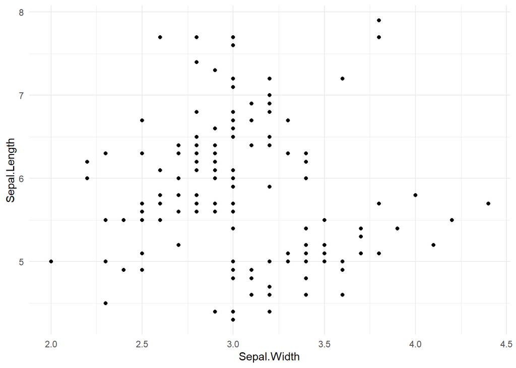

```r
ggplot(data=iris,aes(x=Sepal.Width, y=Sepal.Length)) + geom_point() + theme_minimal()
```

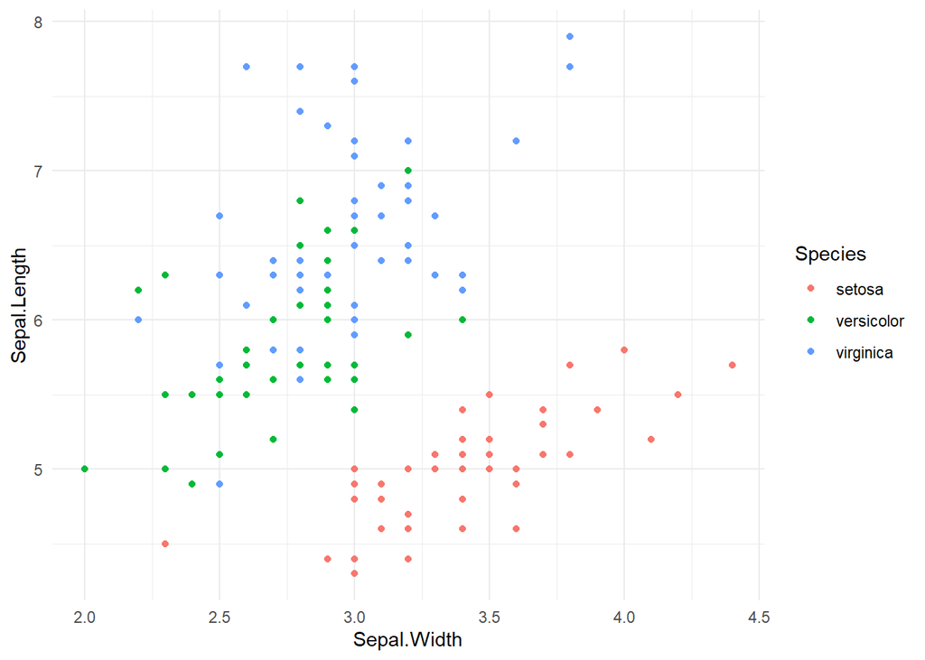

```r
ggplot(data=iris,aes(x=Sepal.Width, y=Sepal.Length,color=Species)) + geom_point() + theme_minimal()#以Species為類別換顏色
```

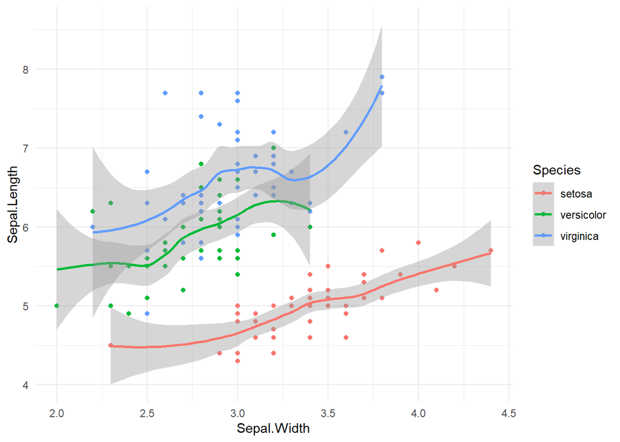

```r
ggplot(data=iris,aes(x=Sepal.Width, y=Sepal.Length,color=Species)) + geom_point() +geom_smooth() + theme_minimal() #加上趨勢線geom_smooth()
```

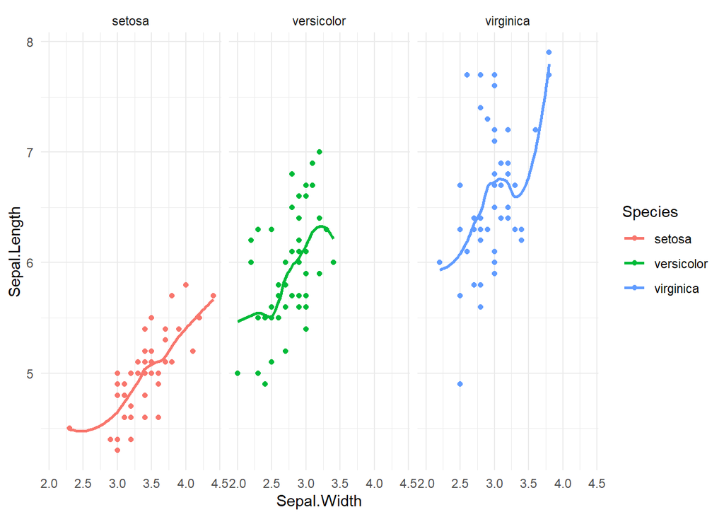

```r
ggplot(data=iris,aes(x=Sepal.Width, y=Sepal.Length,color=Species)) +
geom_point() + geom_smooth(se=FALSE) +facet_wrap(~Species) +theme_minimal()#把三種類別分開畫
```

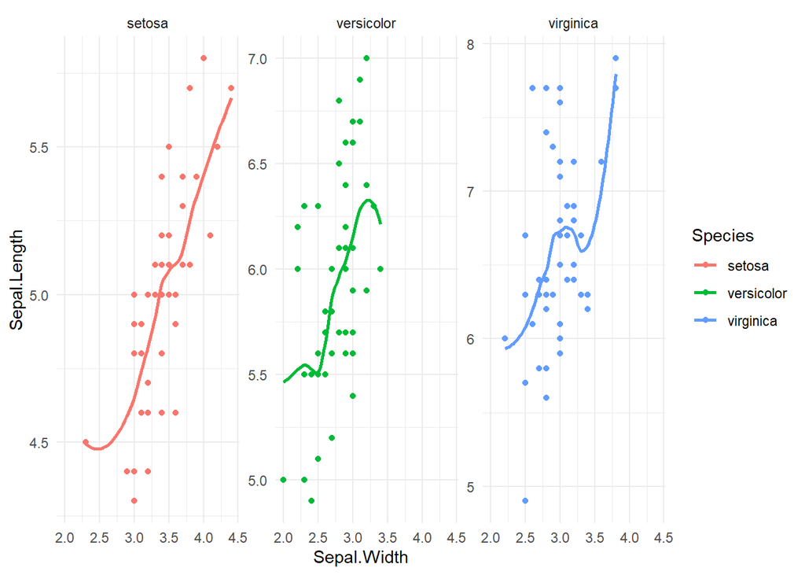

```r
ggplot(data=iris,aes(x=Sepal.Width, y=Sepal.Length,color=Species)) +
geom_point() + geom_smooth(se=FALSE) +facet_wrap(~Species,scale='free_y') +theme_minimal()#分開畫之後，可以給予Free_y
```

### 3-2-2.箱型圖(Box-Plot)

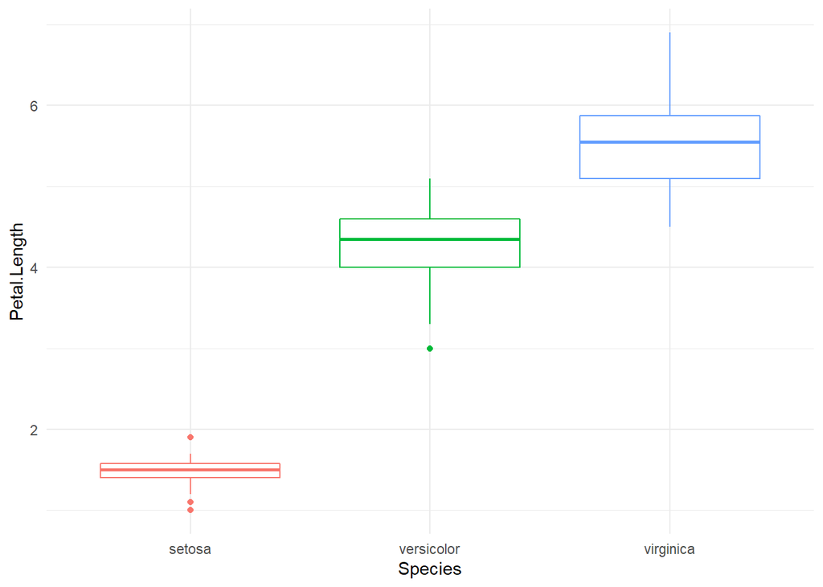

```r
options(repr.plot.width = 5, repr.plot.height = 4)#調整圖形大小

ggplot(data=iris,aes(x=Species, y=Petal.Length,color=Species)) + geom_boxplot() +theme_minimal()+
theme(legend.position="none")
```

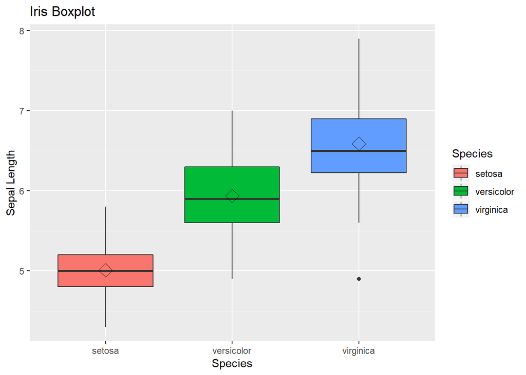

```r
box <- ggplot(data=iris, aes(x=Species, y=Sepal.Length))
box + geom_boxplot(aes(fill=Species)) +
  ylab("Sepal Length") + ggtitle("Iris Boxplot") +
  stat_summary(fun.y=mean, geom="point", shape=5, size=4)
```

### 3-2-3.小提琴圖(Violin Plot)

- 小提琴圖(Violin plot)和箱形圖(boxplot)很類似
- 箱形圖的方形可以顯示出Q1、Q3兩個4分位數，小提琴圖則可以強化資料分佈密度(Density)來展示圖形

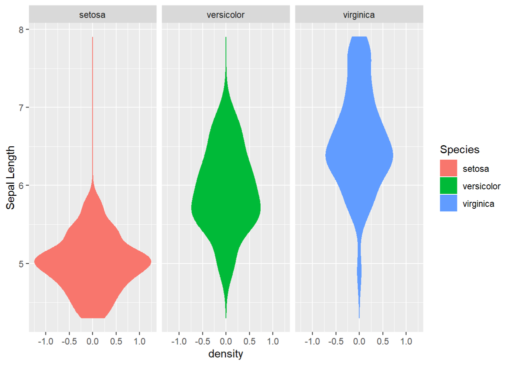

```r
vol <- ggplot(data=iris, aes(x = Sepal.Length))
vol + stat_density(aes(ymax = ..density..,  ymin = -..density..,
                       fill = Species, color = Species),
                   geom = "ribbon", position = "identity") +
  facet_grid(. ~ Species) + coord_flip() + xlab("Sepal Length")
```

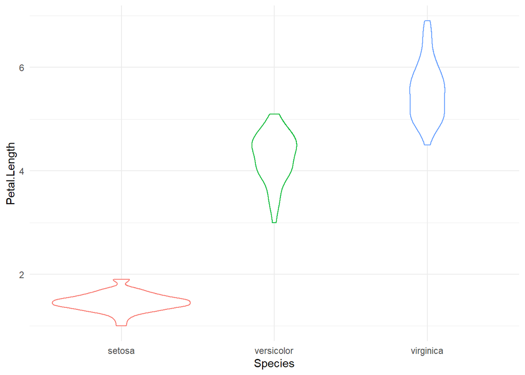

```r
ggplot(data=iris,aes(x=Species, y=Petal.Length,color=Species)) + geom_violin() +theme_minimal()+
theme(legend.position="none")
```

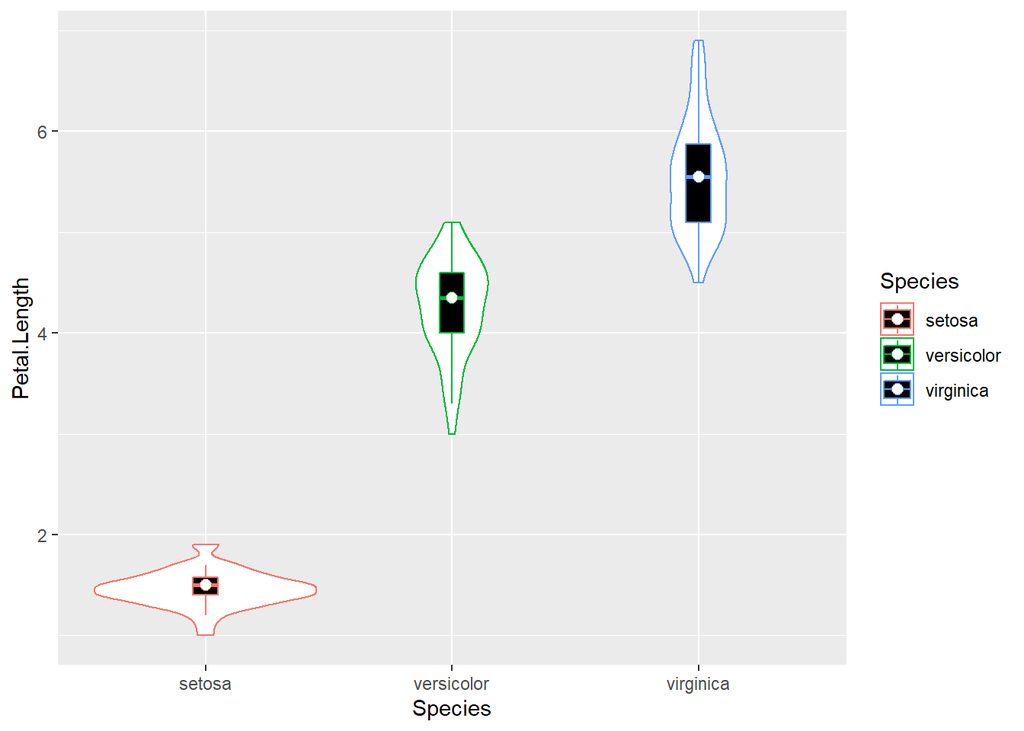

```r
#把箱型圖跟小提琴圖疊起來

p <- ggplot(data=iris, aes(x=Species, y=Petal.Length,color=Species)) #指派一個底圖

p + geom_violin() + geom_boxplot(width=.1, fill="black", outlier.colour=NA) +
stat_summary(fun.y=median, geom="point", fill="white", shape=21, size=2.5)
```

### 3-2-4.直方圖(histogram)

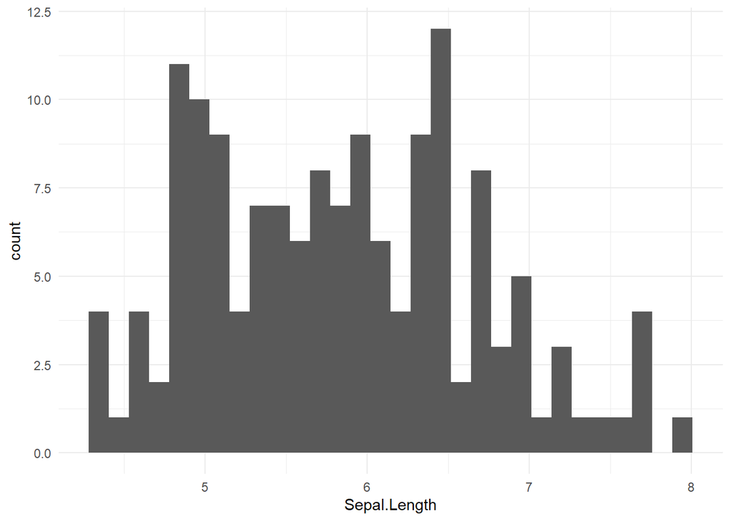

```r
ggplot(data=iris,aes(x=Sepal.Length)) + geom_histogram() +theme_minimal() #直方圖的分箱數（bins）使用了30 個每30單位為一區隔預設值
```

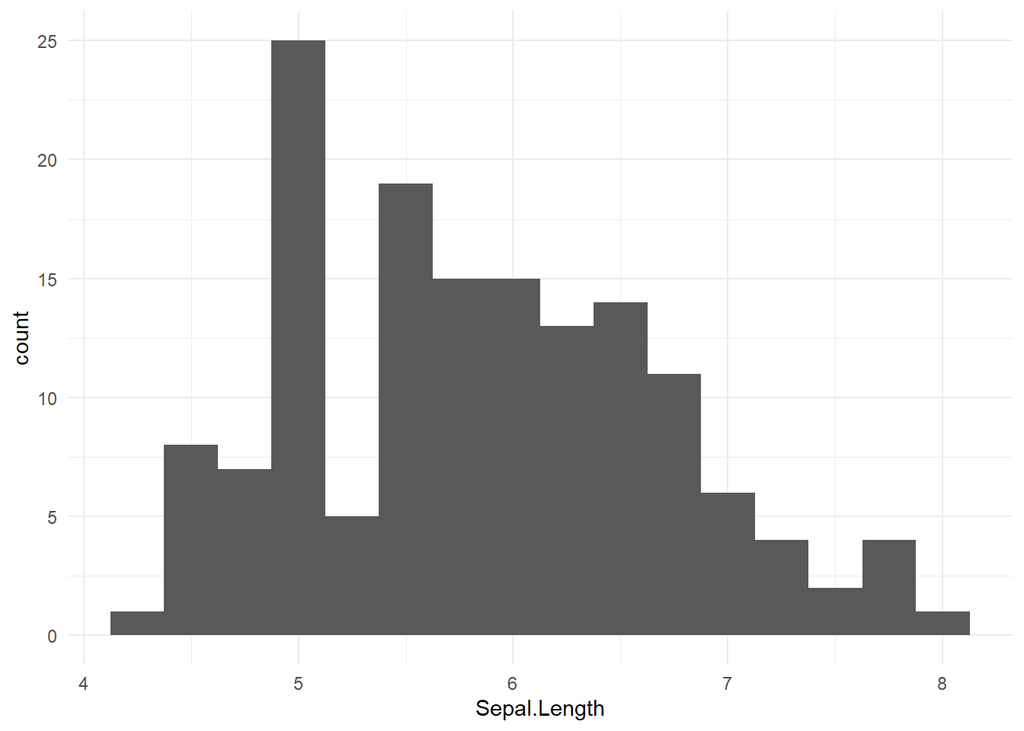

```r
#如果我調整binwidth
ggplot(data=iris,aes(x=Sepal.Length)) + geom_histogram(binwidth=0.25) +theme_minimal()
```

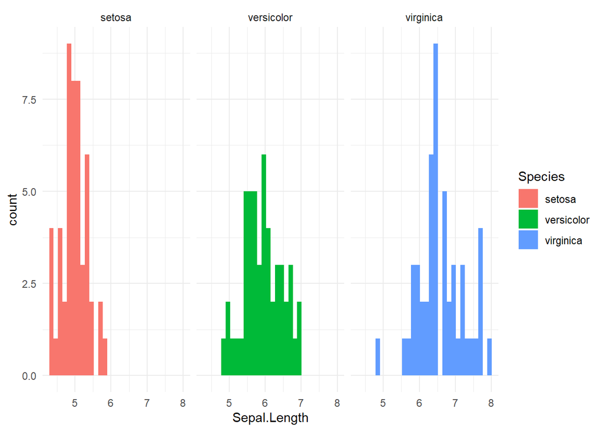

```r
ggplot(data=iris,aes(x=Sepal.Length,fill=Species)) + geom_histogram() +theme_minimal() +facet_wrap(~Species)#facet_wrap()，會把圖由左往右，由上往下排出來
```

### 3-2-5.長條圖(Bar-plot) - stat = “summary” 裡面的功能有：fun.data, fun.y, fun.ymax (設最大值), fun.ymin (設最小值)

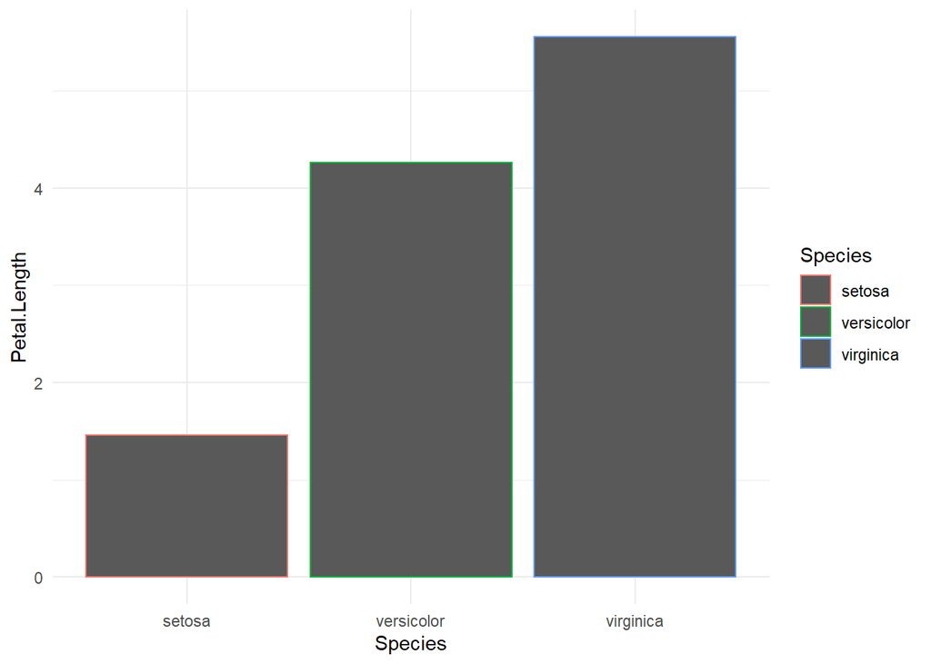

```r
ggplot(data=iris,aes(x=Species,y=Petal.Length,color=Species)) + geom_bar(stat = "summary", fun.y = "mean") +
theme_minimal()
```

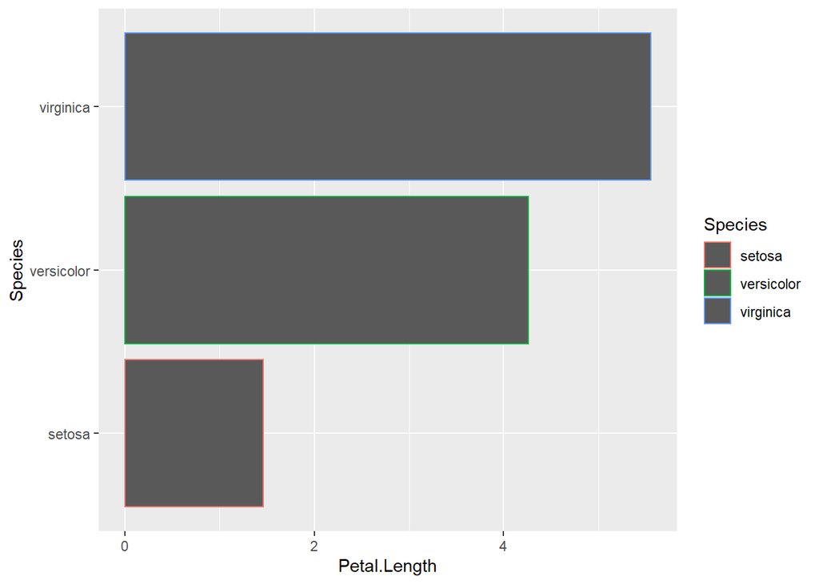

```r
ggplot(data=iris,aes(x=Species,y=Petal.Length,color=Species)) + geom_bar(stat = "summary", fun.y = "mean") + coord_flip()
```

### 3-2-6.圓餅圖(Pie Chart)

- 要用ggplot2畫圓餅圖，要先畫出bar plot，再沿著y軸進行轉軸

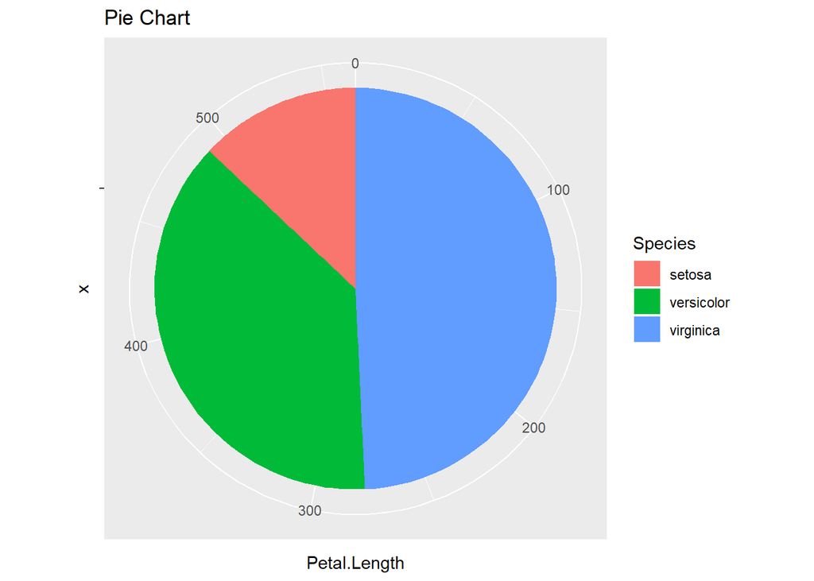

```r
 ggplot(iris, aes(x = "", y = Petal.Length, fill = Species)) +
            geom_bar(width = 1, stat="identity") +
            coord_polar("y", start=0 ) + ggtitle("Pie Chart")
```

### 3-2-7.密度圖(density)

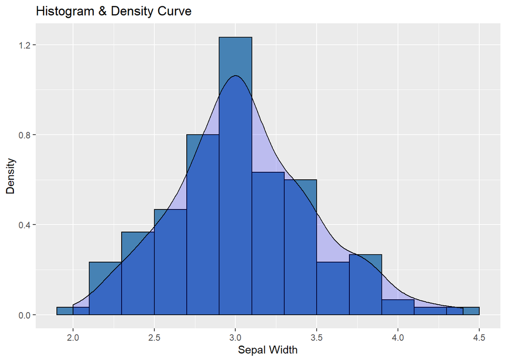

```r
density <- ggplot(data=iris, aes(x=Sepal.Width))
density + geom_histogram(binwidth=0.2, color="black", fill="steelblue", aes(y=..density..)) +
  geom_density(stat="density", alpha=I(0.2), fill="blue") +
  xlab("Sepal Width") +  ylab("Density") + ggtitle("Histogram & Density Curve")
```

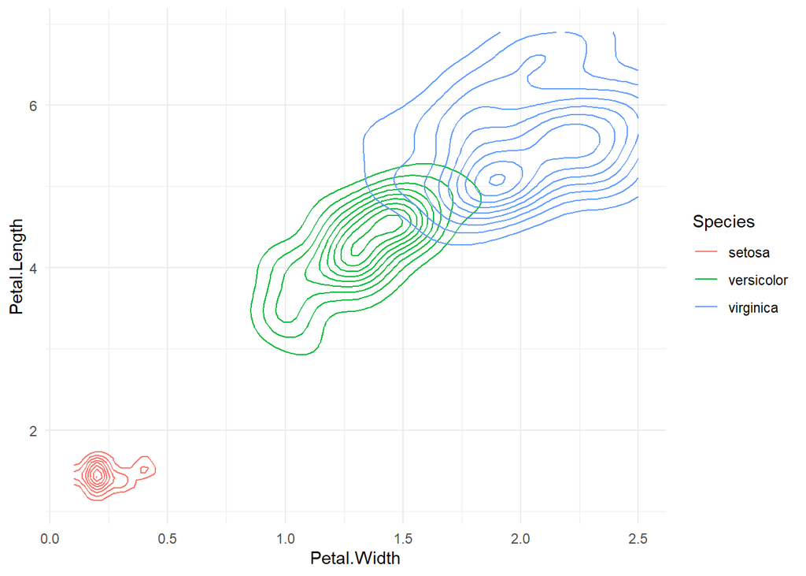

```r
ggplot(data=iris,aes(x=Petal.Width,y=Petal.Length,color=Species)) +geom_density2d()+ theme_minimal()
```

### 資料分佈矩陣圖

```r
#install.packages("GGally")
library(GGally)
```

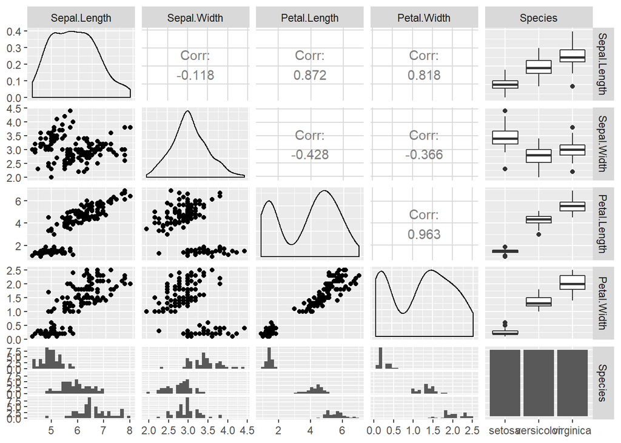

```r
ggpairs(iris)
```

## [PART 4]. 專案一: 婚姻品質是否會導致婚外情?

- 原始論文(A Theory of Extramarital Affairs ) https://fairmodel.econ.yale.edu/rayfair/pdf/1978a200.pdf
- rate_marriage : How rate marriage,
  - 1 = very poor,
  - 2 = poor,
  - 3 = fair,
  - 4 = good,
  - 5 = very good
- age : Age
- yrs_married : No. years married. Interval approximations. See original paper for detailed explanation.
- children : No. children
- religious : How relgious,
  - 1 = not,
  - 2 = mildly,
  - 3 = fairly,
  - 4 = strongly
- educ : Level of education,
  - 9 = grade school,
  - 12 = high school,
  - 14 = some college,
  - 16 = college graduate,
  - 17 = some graduate school,
  - 20 = advanced degree
- occupation :
  - 1 = student,
  - 2 = farming, agriculture; semi-skilled,or unskilled worker;
  - 3 = white-colloar;
  - 4 = teacher counselor social worker, nurse; artist, writers; technician, skilled worker,
  - 5 = managerial, administrative, business,
  - 6 = professional with advanced degree
- occupation_husb : Husband’s occupation. Same as occupation.
- affairs : measure of time spent in extramarital affairs

### 4-1.資料讀入與清理

```r
library(ggplot2)
library(ggcorrplot)
```

```r
fair = read.csv("./data/fair.csv", header=T, sep=",", encoding = "BIG5")#Mac的同學請採用UTF8的檔
class(fair)
```

```
## [1] "data.frame"
```

```r
dim(fair)
```

```
## [1] 6366    9
```

```r
str(fair)
```

```
## 'data.frame':    6366 obs. of  9 variables:
##  $ rate_marriage  : int  3 3 4 4 5 4 5 5 3 3 ...
##  $ age            : num  32 27 22 37 27 27 37 37 22 27 ...
##  $ yrs_married    : num  9 13 2.5 16.5 9 9 23 23 2.5 6 ...
##  $ children       : num  3 3 0 4 1 0 5.5 5.5 0 0 ...
##  $ religious      : int  3 1 1 3 1 2 2 2 2 1 ...
##  $ educ           : int  17 14 16 16 14 14 12 12 12 16 ...
##  $ occupation     : int  2 3 3 5 3 3 5 2 3 3 ...
##  $ occupation_husb: int  5 4 5 5 4 4 4 3 3 5 ...
##  $ affairs        : num  0.111 3.231 1.4 0.727 4.667 ...
```

```r
#資料轉換
fair$occupation <- factor(fair$occupation) #職業為類別變數
fair$occupation_husb <- factor(fair$occupation_husb)#老公的職業為類別變數
fair$religious <- factor(fair$religious)#宗教的虔誠度為類別變數
```

```r
str(fair)
```

```
## 'data.frame':    6366 obs. of  9 variables:
##  $ rate_marriage  : int  3 3 4 4 5 4 5 5 3 3 ...
##  $ age            : num  32 27 22 37 27 27 37 37 22 27 ...
##  $ yrs_married    : num  9 13 2.5 16.5 9 9 23 23 2.5 6 ...
##  $ children       : num  3 3 0 4 1 0 5.5 5.5 0 0 ...
##  $ religious      : Factor w/ 4 levels "1","2","3","4": 3 1 1 3 1 2 2 2 2 1 ...
##  $ educ           : int  17 14 16 16 14 14 12 12 12 16 ...
##  $ occupation     : Factor w/ 6 levels "1","2","3","4",..: 2 3 3 5 3 3 5 2 3 3 ...
##  $ occupation_husb: Factor w/ 6 levels "1","2","3","4",..: 5 4 5 5 4 4 4 3 3 5 ...
##  $ affairs        : num  0.111 3.231 1.4 0.727 4.667 ...
```

### 4-2.敘述性統計

```r
#看一下前後六筆
head(fair)
```

```
##   rate_marriage age yrs_married children religious educ occupation
## 1             3  32         9.0        3         3   17          2
## 2             3  27        13.0        3         1   14          3
## 3             4  22         2.5        0         1   16          3
## 4             4  37        16.5        4         3   16          5
## 5             5  27         9.0        1         1   14          3
## 6             4  27         9.0        0         2   14          3
##   occupation_husb   affairs
## 1               5 0.1111111
## 2               4 3.2307692
## 3               5 1.3999996
## 4               5 0.7272727
## 5               4 4.6666660
## 6               4 4.6666660
```

```r
tail(fair)
```

```
##      rate_marriage age yrs_married children religious educ occupation
## 6361             5  22         2.5        0         2   14          3
## 6362             5  32        13.0        2         3   17          4
## 6363             4  32        13.0        1         1   16          5
## 6364             5  22         2.5        0         2   14          3
## 6365             5  32         6.0        1         3   14          3
## 6366             4  22         2.5        0         2   16          2
##      occupation_husb affairs
## 6361               3       0
## 6362               3       0
## 6363               5       0
## 6364               1       0
## 6365               4       0
## 6366               4       0
```

```r
summary(fair) #基本統計資料
```

```
##  rate_marriage       age         yrs_married        children     religious
##  Min.   :1.00   Min.   :17.50   Min.   : 0.500   Min.   :0.000   1:1021
##  1st Qu.:4.00   1st Qu.:22.00   1st Qu.: 2.500   1st Qu.:0.000   2:2267
##  Median :4.00   Median :27.00   Median : 6.000   Median :1.000   3:2422
##  Mean   :4.11   Mean   :29.08   Mean   : 9.009   Mean   :1.397   4: 656
##  3rd Qu.:5.00   3rd Qu.:32.00   3rd Qu.:16.500   3rd Qu.:2.000
##  Max.   :5.00   Max.   :42.00   Max.   :23.000   Max.   :5.500
##       educ       occupation occupation_husb    affairs
##  Min.   : 9.00   1:  41     1: 229          Min.   : 0.0000
##  1st Qu.:12.00   2: 859     2:1308          1st Qu.: 0.0000
##  Median :14.00   3:2783     3: 490          Median : 0.0000
##  Mean   :14.21   4:1834     4:2030          Mean   : 0.7054
##  3rd Qu.:16.00   5: 740     5:1779          3rd Qu.: 0.4849
##  Max.   :20.00   6: 109     6: 530          Max.   :57.6000
```

```r
library(dplyr)

summarise(group_by(fair, educ), 婚外情平均=mean(affairs)) #分組資料 group_by的使用，教育程度跟婚外情的比例
```

```
## # A tibble: 6 x 2
##    educ 婚外情平均
##   <int>      <dbl>
## 1     9      0.569
## 2    12      0.684
## 3    14      0.824
## 4    16      0.559
## 5    17      0.712
## 6    20      0.531
```

```r
summarise(group_by(fair, occupation), 婚外情平均=mean(affairs)) #分組資料 group_by的使用，職業跟婚外情的比例
```

```
## # A tibble: 6 x 2
##   occupation 婚外情平均
##   <fct>           <dbl>
## 1 1               0.426
## 2 2               0.720
## 3 3               0.755
## 4 4               0.556
## 5 5               0.815
## 6 6               1.19
```

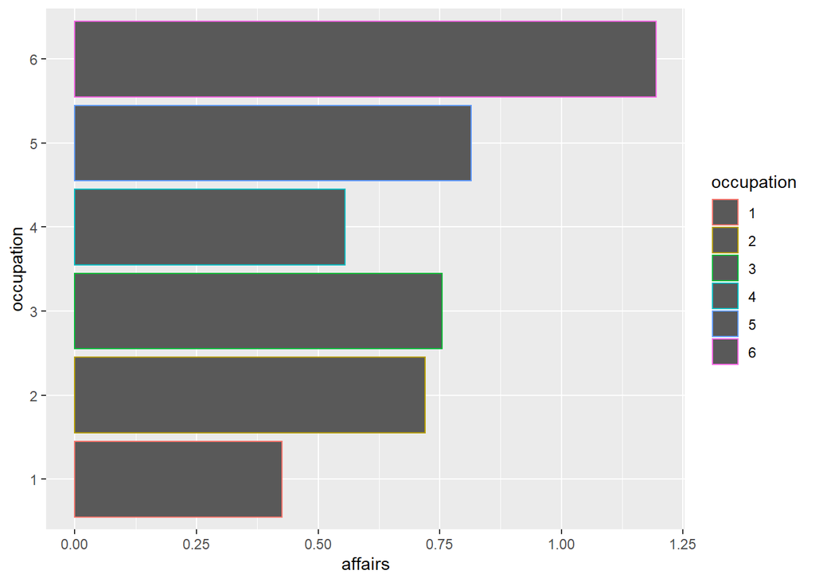

```r
ggplot(data=fair,aes(x=occupation,y=affairs,color=occupation)) + geom_bar(stat = "summary", fun.y = "mean") + coord_flip()
```

### 4-3.相關與ANOVA

- https://rpubs.com/skydome20/R-Note5-First_Practice

### 4-3-1.相關分析

- 因原始資料集中有類別型的資料，因此需要將數值型資料取出

```r
#
fair1<-fair[,c("rate_marriage","age","yrs_married","children","educ","affairs" )]
head(fair1)
```

```
##   rate_marriage age yrs_married children educ   affairs
## 1             3  32         9.0        3   17 0.1111111
## 2             3  27        13.0        3   14 3.2307692
## 3             4  22         2.5        0   16 1.3999996
## 4             4  37        16.5        4   16 0.7272727
## 5             5  27         9.0        1   14 4.6666660
## 6             4  27         9.0        0   14 4.6666660
```

```r
corr<-cor(fair1)
corr
```

```
##               rate_marriage         age yrs_married    children
## rate_marriage    1.00000000 -0.11112684 -0.12897845 -0.12916120
## age             -0.11112684  1.00000000  0.89408184  0.67390214
## yrs_married     -0.12897845  0.89408184  1.00000000  0.77280570
## children        -0.12916120  0.67390214  0.77280570  1.00000000
## educ             0.07986881  0.02795995 -0.10905800 -0.14191814
## affairs         -0.17806816 -0.08996417 -0.08773737 -0.07027831
##                      educ     affairs
## rate_marriage  0.07986881 -0.17806816
## age            0.02795995 -0.08996417
## yrs_married   -0.10905800 -0.08773737
## children      -0.14191814 -0.07027831
## educ           1.00000000 -0.01773985
## affairs       -0.01773985  1.00000000
```

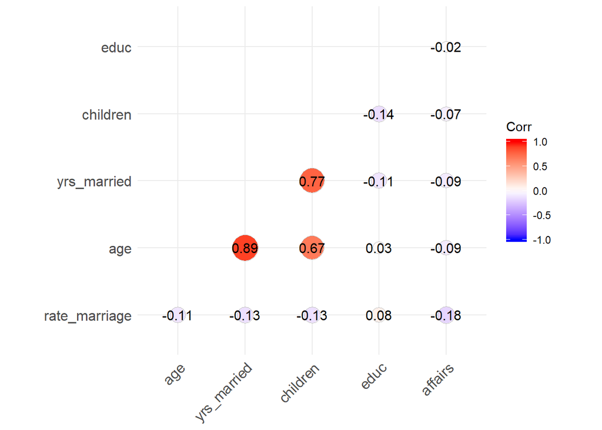

```r
ggcorrplot(corr, lab = TRUE, type = "lower", method="circle")
```

### 4-3-2.ANOVA

#### 我們可以看出，不同職業組別在婚外情比例上有差異

```r
agg1 = aggregate(fair[,c("age","yrs_married","rate_marriage","affairs")],by=list(fair$occupation),FUN=mean)
agg1
```

```
##   Group.1      age yrs_married rate_marriage   affairs
## 1       1 25.45122    5.743902      4.317073 0.4260138
## 2       2 28.48952    9.095460      4.061700 0.7195561
## 3       3 28.56719    8.833812      4.051743 0.7552480
## 4       4 29.52399    8.702563      4.213740 0.5559196
## 5       5 30.58446   10.551351      4.104054 0.8152088
## 6       6 30.67431    8.738532      4.174312 1.1943001
```

#### 我們可以看出，不同宗教信仰強度在婚外情比例上有差異

```r
agg2 = aggregate(fair[,c("age","yrs_married","rate_marriage","affairs")],by=list(fair$religious),FUN=mean)
agg2
```

```
##   Group.1      age yrs_married rate_marriage   affairs
## 1       1 27.70421    7.439765      4.077375 1.2469892
## 2       2 28.61822    8.650640      4.021173 0.7672818
## 3       3 29.53695    9.436416      4.141206 0.5450385
## 4       4 31.15777   11.115854      4.349085 0.2404312
```

#### - H0: 不同職業的婚外情平均數相等

#### - H1: 至少有一種職業的婚外情平均和其他職業不相等

```r
aov<-aov(fair$affairs~as.character(fair$occupation)) #ANOVA
summary(aov)
```

```
##                                 Df Sum Sq Mean Sq F value  Pr(>F)
## as.character(fair$occupation)    5     86  17.249    3.56 0.00324 **
## Residuals                     6360  30815   4.845
## ---
## Signif. codes:  0 '***' 0.001 '**' 0.01 '*' 0.05 '.' 0.1 ' ' 1
```

```r
#進行事後檢定(採用Tukey )
TukeyHSD(aov)
```

```
##   Tukey multiple comparisons of means
##     95% family-wise confidence level
##
## Fit: aov(formula = fair$affairs ~ as.character(fair$occupation))
##
## $`as.character(fair$occupation)`
##            diff         lwr         upr     p adj
## 2-1  0.29354230 -0.70949559  1.29658018 0.9611928
## 3-1  0.32923422 -0.65788227  1.31635071 0.9331044
## 4-1  0.12990581 -0.86091161  1.12072323 0.9990543
## 5-1  0.38919499 -0.61751022  1.39590021 0.8807202
## 6-1  0.76828635 -0.38125618  1.91782888 0.3989478
## 3-2  0.03569192 -0.20921518  0.28059903 0.9984241
## 4-2 -0.16363649 -0.42305832  0.09578535 0.4670068
## 5-2  0.09565270 -0.21904704  0.41035244 0.9544391
## 6-2  0.47474406 -0.16324384  1.11273195 0.2763077
## 4-3 -0.19932841 -0.38804421 -0.01061261 0.0313355
## 5-3  0.05996077 -0.19955780  0.31947935 0.9863084
## 6-3  0.43905213 -0.17359991  1.05170417 0.3180915
## 5-4  0.25928918 -0.01396910  0.53254747 0.0743736
## 6-4  0.63838054  0.01978316  1.25697792 0.0384806
## 6-5  0.37909136 -0.26464691  1.02282963 0.5460139
```

### [小結]: 在alpha=0.05下，我們有顯著的證據支持

- (4-3) 專業工作者與一般白領階級在婚外情平均上有顯著差異
- (6-4) 高階專業人士與專業工作者在婚外情平均上有顯著差異

### [課堂作業]. H0: 不同宗教的虔誠度(religious)的婚外情平均數相等

### 4-4.迴歸分析

- 婚外情到底受到那些因素影響

### 4-4-1.複迴歸分析

```r
model <- lm(formula= affairs ~ ., data=fair1)
summary(model)
```

```
##
## Call:
## lm(formula = affairs ~ ., data = fair1)
##
## Residuals:
##    Min     1Q Median     3Q    Max
## -2.496 -0.814 -0.480  0.063 57.057
##
## Coefficients:
##                Estimate Std. Error t value Pr(>|t|)
## (Intercept)    3.312089   0.261255  12.678   <2e-16 ***
## rate_marriage -0.440991   0.028408 -15.523   <2e-16 ***
## age           -0.015827   0.009181  -1.724   0.0848 .
## yrs_married   -0.015532   0.009910  -1.567   0.1171
## children      -0.036487   0.029847  -1.222   0.2216
## educ          -0.010077   0.013063  -0.771   0.4405
## ---
## Signif. codes:  0 '***' 0.001 '**' 0.01 '*' 0.05 '.' 0.1 ' ' 1
##
## Residual standard error: 2.154 on 6360 degrees of freedom
## Multiple R-squared:  0.04504,    Adjusted R-squared:  0.04429
## F-statistic: 59.99 on 5 and 6360 DF,  p-value: < 2.2e-16
```

### [小結]. 在alpha=0.05下，我們有顯著的證據支持，婚姻品質(rate_marriage)對婚外情有負向的影響

### 4-4-2.模型診斷(迴歸基本假設分析)

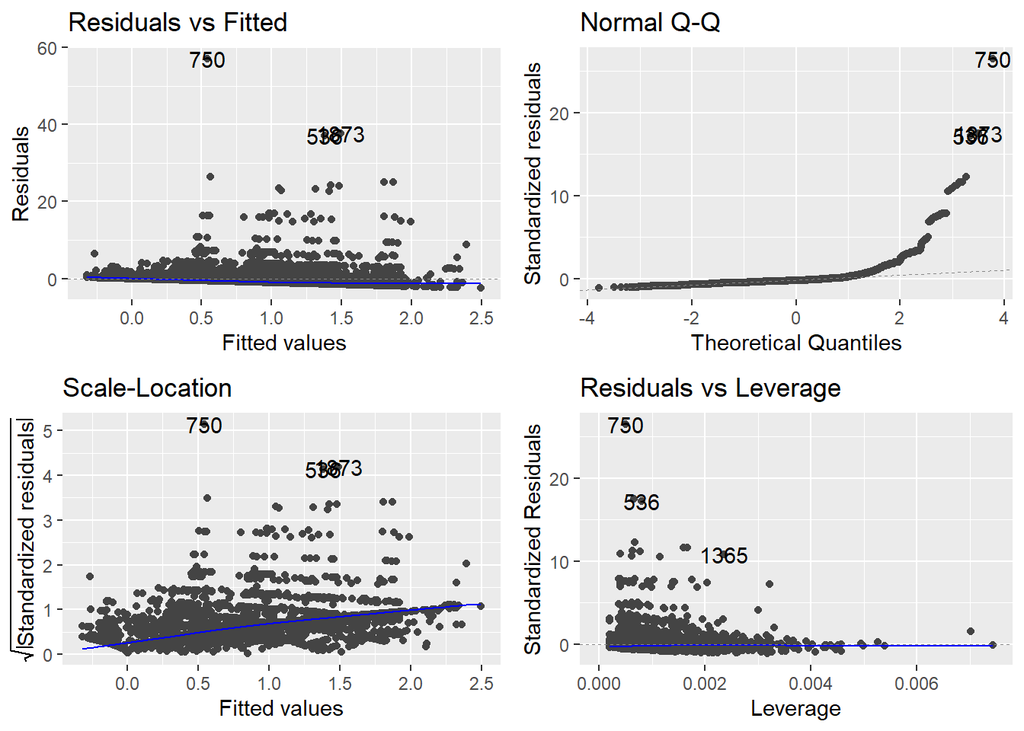

```r
#理論上我們應該採用以下
#shapiro.test(model$residual)#用來檢驗殘差的常態性
#虛無假設H0:殘差服從常態分配，因為p-value > 0.05，代表不會拒絕H0

#但因為shapiro.test 設定sample size <5000，不適合此例，因此我們採用QQ-Plot

#install.packages("ggfortify")
library(ggfortify)

autoplot(model)
```

### Q-Q plot 圖中會加入一條常態直線圖，當 Q-Q plot 散佈圖在此直線附近時，代表樣本資料來自常態分佈

```r
require(car)
```

```r
durbinWatsonTest(model)#檢驗殘差的獨立性
```

```
##  lag Autocorrelation D-W Statistic p-value
##    1       0.2096185      1.580698       0
##  Alternative hypothesis: rho != 0
```

```r
#虛無假設H0:殘差間相互獨立，因為p-value < 0.05，代表拒絕H0
#殘差獨立性檢定的 p-value 也非常小，所以也拒絕虛無假設，亦即殘差值的獨立性假設是不合理的。
```

```r
ncvTest(model)#殘差的變異數同質性
```

```
## Non-constant Variance Score Test
## Variance formula: ~ fitted.values
## Chisquare = 2105.858, Df = 1, p = < 2.22e-16
```

```r
#虛無假設H0:殘差變異數具有同質性，因為p-value < 0.05，代表拒絕H0。(這表示上面的線性模型無法使用)
#殘差的變異數沒有符合同質性的假設
```

## [PART 5]. 專案二:我想買房子(房屋實價登錄資料集)

### **[說明]**

#### 資料內容：登記日期自 108年7月11 至 108年7月20日之買賣案件

#### 原始資料刪除:

- - 交易標的: 土地、車位
  - 建物型態: 工廠、其他、倉庫、農舍、廠辦、辦公商業大樓
  - 交易與建築年月不符

#### 屋齡小於一年的以中位數0.5計

#### 房屋型態定義

- - 華廈(10層含以下有電梯)、
  - 套房(1房1廳1衛)、
  - 公寓(5樓含以下無電梯)、
  - 大樓(11層含以上有電梯)

```r
Data = read.csv("./data/housesale.csv", header=T, sep=",",encoding = "BIG5")#Mac的同學請採用UTF8的檔
dim(Data)
```

```
## [1] 6170   23
```

```r
str(Data)
```

```
## 'data.frame':    6170 obs. of  23 variables:
##  $ 行政區                : Factor w/ 259 levels "宜蘭縣三星鄉",..: 1 1 1 2 2 2 2 2 2 2 ...
##  $ 縣市                  : Factor w/ 21 levels "宜蘭縣","花蓮縣",..: 1 1 1 1 1 1 1 1 1 1 ...
##  $ 鄉鎮市                : Factor w/ 253 levels "七股區","七堵區",..: 11 11 11 41 41 41 41 41 41 41 ...
##  $ 建物區段門牌          : Factor w/ 4801 levels "七股區大埕里10鄰大埕301~330號",..: 212 213 214 986 985 988 980 983 977 984 ...
##  $ 交易標的              : Factor w/ 3 levels "房地(土地+建物)",..: 2 1 1 2 2 1 1 1 1 1 ...
##  $ 土地坪數              : num  34.25 49.06 41.88 6.76 7.6 ...
##  $ 交易年月日            : int  1080620 1080613 1080610 1080601 1080615 1080409 1080628 1080621 1080622 1080601 ...
##  $ 交易年                : int  108 108 108 108 108 108 108 108 108 108 ...
##  $ 建築完成年月          : int  1030604 830204 1070719 1021015 1021015 320930 880128 840524 831227 661229 ...
##  $ 完成年                : int  103 83 107 102 102 32 88 84 83 66 ...
##  $ 屋齡                  : num  5 25 1 6 6 76 20 24 25 42 ...
##  $ 型態                  : Factor w/ 6 levels "公寓","住宅大樓",..: 5 5 5 2 2 5 4 4 4 5 ...
##  $ 主要用途              : Factor w/ 13 levels "","工業用","住工用",..: 5 8 5 8 8 5 5 8 5 5 ...
##  $ 主要建材              : Factor w/ 16 levels "土造","土磚石混合造",..: 15 15 7 15 15 3 15 15 15 7 ...
##  $ 面積坪數              : num  69.7 58.1 59.5 48.2 53.2 ...
##  $ 管理                  : Factor w/ 2 levels "有","無": 2 2 1 1 1 2 1 2 1 2 ...
##  $ 房價                  : int  9800000 4600000 7500000 9520000 11300000 10710000 320000 2600000 2800000 6800000 ...
##  $ 單價元平方公尺        : int  42516 23946 38139 59743 64237 281842 5737 26031 27578 65422 ...
##  $ 車位類別              : Factor w/ 8 levels "","一樓平面",..: 2 1 1 6 6 1 1 1 1 1 ...
##  $ 車位                  : Factor w/ 2 levels "有車位","無車位": 1 2 2 1 1 2 2 2 2 2 ...
##  $ 車位移轉總面積平方公尺: num  0 0 0 0 0 0 0 0 0 0 ...
##  $ 車位總價元            : int  0 0 0 0 0 0 0 0 0 0 ...
##  $ 備註                  : Factor w/ 371 levels "","1、出賣人不負任何費用，本案所有稅費全由買方負擔。",..: 1 1 1 1 1 146 1 1 1 146 ...
```

```r
#看一下前後六筆
head(Data)
```

```
##         行政區   縣市 鄉鎮市                建物區段門牌
## 1 宜蘭縣三星鄉 宜蘭縣 三星鄉 三星鄉三星路二段99巷31~60號
## 2 宜蘭縣三星鄉 宜蘭縣 三星鄉          三星鄉東興路1~30號
## 3 宜蘭縣三星鄉 宜蘭縣 三星鄉   三星鄉楓林一路175巷1~30號
## 4 宜蘭縣五結鄉 宜蘭縣 五結鄉         五結鄉清水路31~60號
## 5 宜蘭縣五結鄉 宜蘭縣 五結鄉          五結鄉清水路1~30號
## 6 宜蘭縣五結鄉 宜蘭縣 五結鄉  五結鄉興盛北路182巷31~60號
##               交易標的   土地坪數 交易年月日 交易年 建築完成年月 完成年
## 1 房地(土地+建物)+車位  34.246025    1080620    108      1030604    103
## 2      房地(土地+建物)  49.059450    1080613    108       830204     83
## 3      房地(土地+建物)  41.884150    1080610    108      1070719    107
## 4 房地(土地+建物)+車位   6.760875    1080601    108      1021015    102
## 5 房地(土地+建物)+車位   7.604850    1080615    108      1021015    102
## 6      房地(土地+建物) 119.015600    1080409    108       320930     32
##   屋齡     型態       主要用途       主要建材 面積坪數 管理     房價
```

[output cut: 20 more lines]

```r
tail(Data)
```

```
##            行政區   縣市 鄉鎮市              建物區段門牌        交易標的
## 6165 澎湖縣馬公市 澎湖縣 馬公市         馬公市菜園61~90號 房地(土地+建物)
## 6166 澎湖縣馬公市 澎湖縣 馬公市         馬公市菜園61~90號 房地(土地+建物)
## 6167 澎湖縣馬公市 澎湖縣 馬公市       馬公市三多路31~60號 房地(土地+建物)
## 6168 澎湖縣馬公市 澎湖縣 馬公市 馬公市五福路3巷32弄1~30號 房地(土地+建物)
## 6169 澎湖縣馬公市 澎湖縣 馬公市        馬公市後窟潭1~30號 房地(土地+建物)
## 6170 澎湖縣馬公市 澎湖縣 馬公市     馬公市貿商街121~150號 房地(土地+建物)
##      土地坪數 交易年月日 交易年 建築完成年月 完成年 屋齡     型態
## 6165  6.61870    1080610    108      1080418    108  0.5     華廈
## 6166  6.68525    1080610    108      1080418    108  0.5     華廈
## 6167  3.78125    1080703    108       850215     85 23.0     套房
## 6168 23.12612    1080422    108       740809     74 34.0   透天厝
## 6169 29.53912    1080701    108       870810     87 21.0   透天厝
## 6170  9.49850    1080523    108       950629     95 13.0 住宅大樓
##            主要用途           主要建材 面積坪數 管理    房價
## 6165 見其他登記事項       鋼筋混凝土造 23.63130   有 3420000
## 6166 見其他登記事項       鋼筋混凝土造 23.86725   有 3580000
## 6167         住家用       鋼筋混凝土造 24.36638   有 2280000
## 6168         住家用 鋼筋混凝土加強磚造 40.14175   無 4900000
## 6169         住家用       鋼筋混凝土造 58.40065   無 6500000
## 6170 見其他登記事項       鋼筋混凝土造 63.88800   有 5850000
##      單價元平方公尺 車位類別   車位 車位移轉總面積平方公尺 車位總價元 備註
## 6165          43779          無車位                      0          0
## 6166          45374          無車位                      0          0
## 6167          28305          無車位                      0          0
## 6168          36925          無車位                      0          0
## 6169          33668          無車位                      0          0
## 6170          27699          無車位                      0          0
```

### 5-1. 敘述性統計

```r
dat1<-Data[,c("行政區","縣市","鄉鎮市","屋齡","型態","面積坪數","管理","房價","車位" )]

dat1[sample(1:nrow(dat1),6),] #隨機抓六筆出來看
```

```
##            行政區   縣市 鄉鎮市 屋齡     型態 面積坪數 管理     房價
## 2245 高雄市鳳山區 高雄市 鳳山區 47.0   透天厝 22.62700   無  6200000
## 3398 新北市新店區 新北市 新店區 20.0 住宅大樓 39.89068   有 10500000
## 1942 高雄市苓雅區 高雄市 苓雅區  0.5 住宅大樓 17.35745   有  4380000
## 1396 桃園市龜山區 桃園市 龜山區 11.0     華廈 25.60360   有  4350000
## 1658 高雄市小港區 高雄市 小港區 24.0 住宅大樓 53.02522   有  5890000
## 1203 桃園市新屋區 桃園市 新屋區  0.5 住宅大樓 25.39487   有  3780000
##        車位
## 2245 無車位
## 3398 有車位
## 1942 無車位
## 1396 無車位
## 1658 有車位
## 1203 無車位
```

```r
summary(dat1) #基本統計資料
```

```
##           行政區          縣市          鄉鎮市          屋齡
##  桃園市桃園區: 286   新北市 :1206   桃園區 : 286   Min.   : 0.50
##  桃園市中壢區: 186   桃園市 : 958   中壢區 : 186   1st Qu.: 2.00
##  嘉義市嘉義市: 175   臺中市 : 955   嘉義市 : 175   Median :13.00
##  臺中市西屯區: 135   高雄市 : 851   西屯區 : 135   Mean   :16.48
##  新北市淡水區: 134   臺南市 : 487   淡水區 : 134   3rd Qu.:26.00
##  新北市林口區: 128   臺北市 : 272   林口區 : 128   Max.   :96.00
##  (Other)     :5126   (Other):1441   (Other):5126
##        型態         面積坪數        管理           房價
##  公寓    : 649   Min.   :   0.006   有:3650   Min.   :     1500
##  住宅大樓:2538   1st Qu.:  28.747   無:2520   1st Qu.:  4750000
##  店面    :  89   Median :  40.875             Median :  7600000
##  套房    : 385   Mean   :  45.309             Mean   : 10132618
##  透天厝  :1676   3rd Qu.:  55.250             3rd Qu.: 11880000
##  華廈    : 833   Max.   :1936.130             Max.   :285000000
##
##      車位
##  有車位:2437
##  無車位:3733
##
##
##
##
##
```

### Q:如果我想知道不同房屋型態平均來說多少錢?

```r
# pivotal table
library(dplyr)
summarise(group_by(dat1, 型態), 平均=mean(房價)) #分組資料 group_by的使用
```

```
## # A tibble: 6 x 2
##   型態          平均
##   <fct>        <dbl>
## 1 公寓      5945176.
## 2 住宅大樓 12429013.
## 3 店面     20076588.
## 4 套房      3022406.
## 5 透天厝   10487284.
## 6 華廈      7908607.
```

### Q: 各縣市在不同型態的房屋數量

```r
table1=table(dat1$"縣市", dat1$"型態") #卡方列聯表
table1
```

```
##
##          公寓 住宅大樓 店面 套房 透天厝 華廈
##   宜蘭縣   12        7    2   17     67   18
##   花蓮縣    1        3    0   13     35   18
##   金門縣    7        0    0    0      8    2
##   南投縣    1        9    3    0     49   11
##   屏東縣   10       17    0    7     89   19
##   苗栗縣    3       24    3    6     46   26
##   桃園市   81      511   20   41    185  120
##   高雄市   78      416    9   29    251   68
##   基隆市   41       33    3    4      6   25
##   雲林縣    3        3    0    1     51    8
##   新北市  223      672   13   50     32  216
##   新竹市   10       52    2   14     31   14
##   新竹縣    4       80    4    9     55   23
##   嘉義市    6       26    1   67     56   19
##   嘉義縣    7        2    3    2     57    2
##   彰化縣    3       14    4    4    103   14
##   臺中市   65      418   13   53    290  116
##   臺北市   60      114    3   38      5   52
##   臺東縣    2        2    1    3     17    1
##   臺南市   32      133    5   25    239   53
##   澎湖縣    0        2    0    2      4    8
```

### 5-2. 資料視覺化

- 我們採用ggplot2套件

```r
library(ggplot2)
```

```r
count <- sort(table(dat1$"縣市"),decreasing=TRUE)[1:10] #各縣市的數量排序(遞減) ，取前10個縣市
zone <- factor(names(count),levels=names(count),ordered=TRUE) #把lable 放上去
df <- data.frame(count, zone)
df
```

```
##      Var1 Freq   zone
## 1  新北市 1206 新北市
## 2  桃園市  958 桃園市
## 3  臺中市  955 臺中市
## 4  高雄市  851 高雄市
## 5  臺南市  487 臺南市
## 6  臺北市  272 臺北市
## 7  新竹縣  175 新竹縣
## 8  嘉義市  175 嘉義市
## 9  屏東縣  142 屏東縣
## 10 彰化縣  142 彰化縣
```

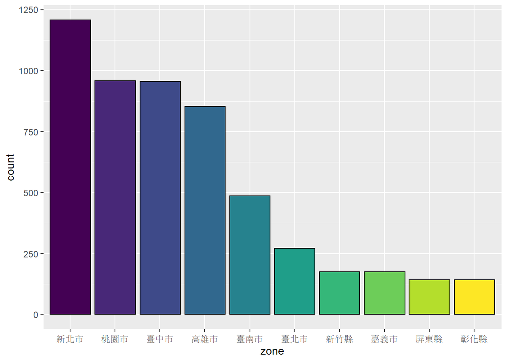

```r
g <- ggplot(data=df, aes(x=zone,y=count,fill=zone)) +
  geom_bar(colour="black",stat="identity") +
  guides(fill=FALSE)

g
```

```r
# g + theme_gray(base_family="STHeiti") # 顯示中文字 Mac user only
```

### 5-3.Data Mining: Decision Tree

- 回到一開始的問題: **我想買房子**
- 為了教學方便，同時減少城鄉誤差造成的差距，我們只取**“臺北市”、“新北市”、“基隆市”、“桃園市”**

```r
library(dplyr)#dplyr是對資料做整理的套件
library(ggplot2)#ggplot2 是劃圖套件
library(rpart)# rpart 是決策樹套件
library(rpart.plot)# rpart.plot是決策樹的繪圖套件
```

### 5-3-1.決策樹

```r
dat2 <- dat1[dat1$縣市 %in% c("臺北市","新北市","基隆市","桃園市") ,]
nrow(dat2)
```

```
## [1] 2548
```

```r
head(dat2)
```

```
##           行政區   縣市 鄉鎮市 屋齡     型態  面積坪數 管理     房價
## 534 桃園市八德區 桃園市 八德區    4   透天厝 248.76390   有 72000000
## 535 桃園市八德區 桃園市 八德區    1 住宅大樓  34.92363   有  6250000
## 536 桃園市八德區 桃園市 八德區    3 住宅大樓  36.54200   有  6100000
## 537 桃園市八德區 桃園市 八德區    1     華廈  40.55315   有  6830000
## 538 桃園市八德區 桃園市 八德區   25     華廈  41.79945   無  6200000
## 539 桃園市八德區 桃園市 八德區    1 住宅大樓  42.48007   有  7820000
##       車位
## 534 有車位
## 535 有車位
## 536 有車位
## 537 有車位
## 538 有車位
## 539 有車位
```

```r
dat2[sample(1:nrow(dat2),10),] #隨機抓10筆出來看
```

```
##            行政區   縣市 鄉鎮市 屋齡     型態  面積坪數 管理     房價
## 1276 桃園市楊梅區 桃園市 楊梅區    3 住宅大樓 58.594250   有  9900000
## 2746 新北市中和區 新北市 中和區   21     華廈 33.852775   有 10300000
## 769  桃園市中壢區 桃園市 中壢區   18     套房 11.791450   有  2600000
## 729  桃園市中壢區 桃園市 中壢區   11 住宅大樓 61.722100   有  8600000
## 3533 新北市新莊區 新北市 新莊區   44     公寓 18.624925   無  9660000
## 962  桃園市桃園區 桃園市 桃園區    6 住宅大樓 37.431350   有  6900000
## 3078 新北市板橋區 新北市 板橋區   32     公寓 34.230900   無 10000000
## 5433 臺北市中山區 臺北市 中山區   39 住宅大樓  4.098875   有  1966400
## 2624 新北市三峽區 新北市 三峽區   12 住宅大樓 43.898800   有 11050000
## 1429 桃園市蘆竹區 桃園市 蘆竹區   14 住宅大樓 44.177100   有  9180000
##        車位
## 1276 有車位
## 2746 有車位
## 769  無車位
## 729  有車位
## 3533 無車位
## 962  有車位
## 3078 無車位
## 5433 無車位
## 2624 有車位
## 1429 有車位
```

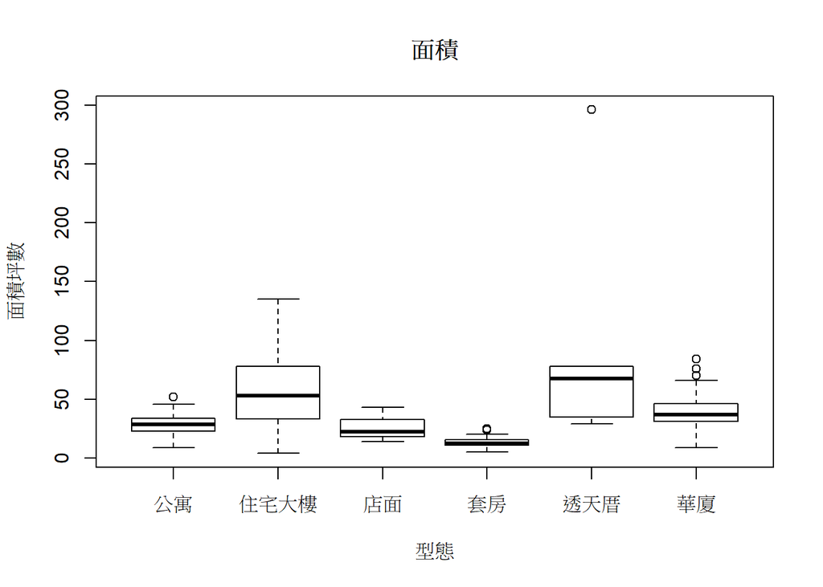

```r
boxplot(面積坪數~型態,data=subset(dat2,縣市=="臺北市"),ylab="面積坪數",main="面積")
```

### 還記得我們的問題嗎? (我想買房子)

- 所以問題是:*我該買在哪裡*?

#### 縣市~型態+面積坪數+屋齡+房價

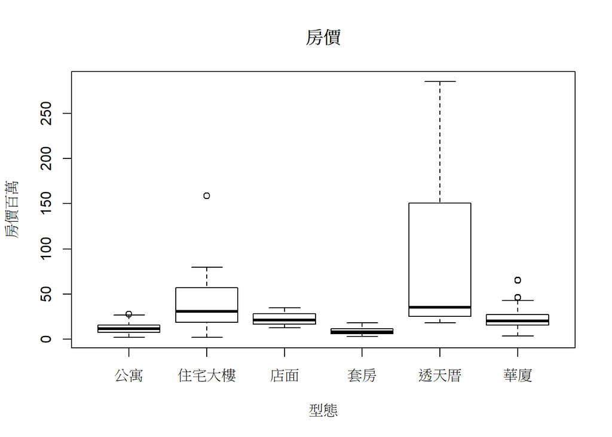

```r
dat2$房價百萬 <- dat2$房價/10^6

boxplot(房價百萬~型態,data=subset(dat2,縣市=="臺北市"),ylab="房價百萬",main="房價")
```

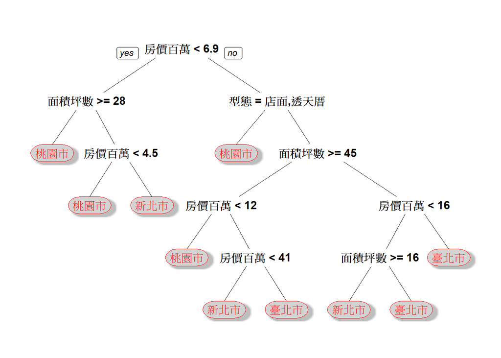

```r
fit2 <- rpart(縣市~型態+面積坪數+屋齡+房價百萬,data=dat2)
prp(fit2,col=2,box.col="lightgray",shadow.col="gray")
```

### 5-3-2.預測正確率

```r
result = rpart(縣市~型態+面積坪數+屋齡+房價百萬, data=dat2)
Y = dat2$縣市
Ypred = predict(result, type="class")

t = table(Y, Ypred)   # 同時顯示 t 的內容
cat("預測正確率 = ", sum(diag(t))/sum(t), "\n" )
```

```
## 預測正確率 =  0.6954474
```

### 5-5-3. 稀疏矩陣

```r
confmatrix = function(Y,Ypred)
{

  tab = table(Y,Ypredict=Ypred)
  print(tab)
  p = sum(diag(t))/sum(t)*100
  cat("\n\n預測正確率 = ",p,"% \n")
}

confmatrix(dat2$縣市, Ypred)
```

```
##         Ypredict
## Y        宜蘭縣 花蓮縣 金門縣 南投縣 屏東縣 苗栗縣 桃園市 高雄市 基隆市
##   宜蘭縣      0      0      0      0      0      0      0      0      0
##   花蓮縣      0      0      0      0      0      0      0      0      0
##   金門縣      0      0      0      0      0      0      0      0      0
##   南投縣      0      0      0      0      0      0      0      0      0
##   屏東縣      0      0      0      0      0      0      0      0      0
##   苗栗縣      0      0      0      0      0      0      0      0      0
##   桃園市      0      0      0      0      0      0    751      0      0
##   高雄市      0      0      0      0      0      0      0      0      0
##   基隆市      0      0      0      0      0      0     96      0      0
##   雲林縣      0      0      0      0      0      0      0      0      0
##   新北市      0      0      0      0      0      0    262      0      0
##   新竹市      0      0      0      0      0      0      0      0      0
##   新竹縣      0      0      0      0      0      0      0      0      0
##   嘉義市      0      0      0      0      0      0      0      0      0
##   嘉義縣      0      0      0      0      0      0      0      0      0
##   彰化縣      0      0      0      0      0      0      0      0      0
##   臺中市      0      0      0      0      0      0      0      0      0
##   臺北市      0      0      0      0      0      0     24      0      0
##   臺東縣      0      0      0      0      0      0      0      0      0
##   臺南市      0      0      0      0      0      0      0      0      0
##   澎湖縣      0      0      0      0      0      0      0      0      0
##         Ypredict
## Y        雲林縣 新北市 新竹市 新竹縣 嘉義市 嘉義縣 彰化縣 臺中市 臺北市
##   宜蘭縣      0      0      0      0      0      0      0      0      0
##   花蓮縣      0      0      0      0      0      0      0      0      0
##   金門縣      0      0      0      0      0      0      0      0      0
##   南投縣      0      0      0      0      0      0      0      0      0
##   屏東縣      0      0      0      0      0      0      0      0      0
##   苗栗縣      0      0      0      0      0      0      0      0      0
##   桃園市      0    203      0      0      0      0      0      0      4
##   高雄市      0      0      0      0      0      0      0      0      0
##   基隆市      0     16      0      0      0      0      0      0      0
##   雲林縣      0      0      0      0      0      0      0      0      0
##   新北市      0    875      0      0      0      0      0      0     69
##   新竹市      0      0      0      0      0      0      0      0      0
##   新竹縣      0      0      0      0      0      0      0      0      0
##   嘉義市      0      0      0      0      0      0      0      0      0
##   嘉義縣      0      0      0      0      0      0      0      0      0
```

[output cut: 17 more lines]

```
##   雲林縣      0      0      0
##   新北市      0      0      0
##   新竹市      0      0      0
##   新竹縣      0      0      0
##   嘉義市      0      0      0
##   嘉義縣      0      0      0
##   彰化縣      0      0      0
##   臺中市      0      0      0
##   臺北市      0      0      0
##   臺東縣      0      0      0
##   臺南市      0      0      0
##   澎湖縣      0      0      0
##
##
## 預測正確率 =  69.54474 %
```

### [課堂作業]. 請你挑選你喜歡的1-3個城市，做出決策樹

## [附件補充資料A]. 房屋實價登錄Regression

### A-1.Regression

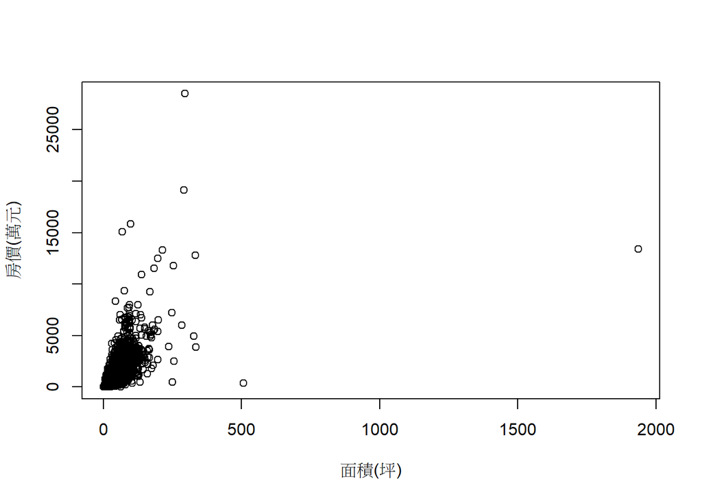

```r
plot(dat1$面積坪數,dat1$房價/10^4,xlab="面積(坪)",ylab="房價(萬元)")
```

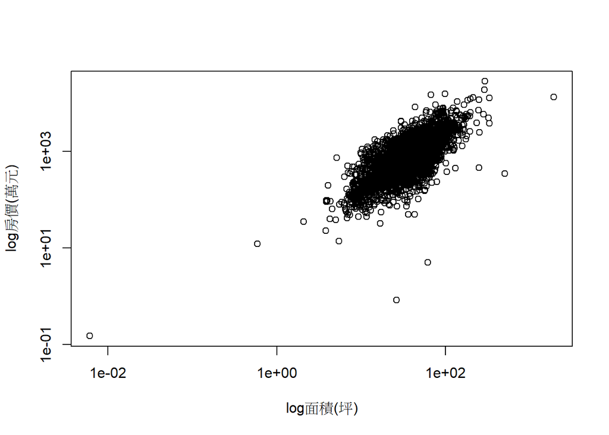

```r
plot(dat1$面積坪數,dat1$房價/10^4,xlab="log面積(坪)",ylab="log房價(萬元)",log="xy") #因為有一個坪數超高的，所以取log
```

```r
cor(dat1$"面積坪數",dat1$"房價"/10^4) #相關係數
```

```
## [1] 0.5792532
```

### A-1-1. Simple Regression

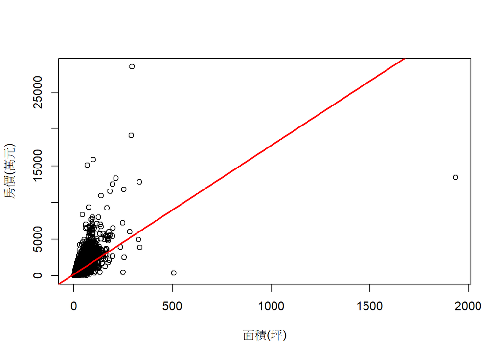

```r
x <- dat1$面積坪數
y <- dat1$房價/10^4

plot(x,y,xlab="面積(坪)",ylab="房價(萬元)")
fit <- lm(y~x)
abline(fit,col=2,lwd=2)
```

```r
summary(fit) # 迴歸係數
```

```
##
## Call:
## lm(formula = y ~ x)
##
## Residuals:
##      Min       1Q   Median       3Q      Max
## -20804.9   -339.5   -184.5    116.4  23084.5
##
## Coefficients:
##             Estimate Std. Error t value Pr(>|t|)
## (Intercept) 217.3100    18.1879   11.95   <2e-16 ***
## x            17.5673     0.3148   55.81   <2e-16 ***
## ---
## Signif. codes:  0 '***' 0.001 '**' 0.01 '*' 0.05 '.' 0.1 ' ' 1
##
## Residual standard error: 886.6 on 6168 degrees of freedom
## Multiple R-squared:  0.3355, Adjusted R-squared:  0.3354
## F-statistic:  3115 on 1 and 6168 DF,  p-value: < 2.2e-16
```

### 如果只看台北市呢

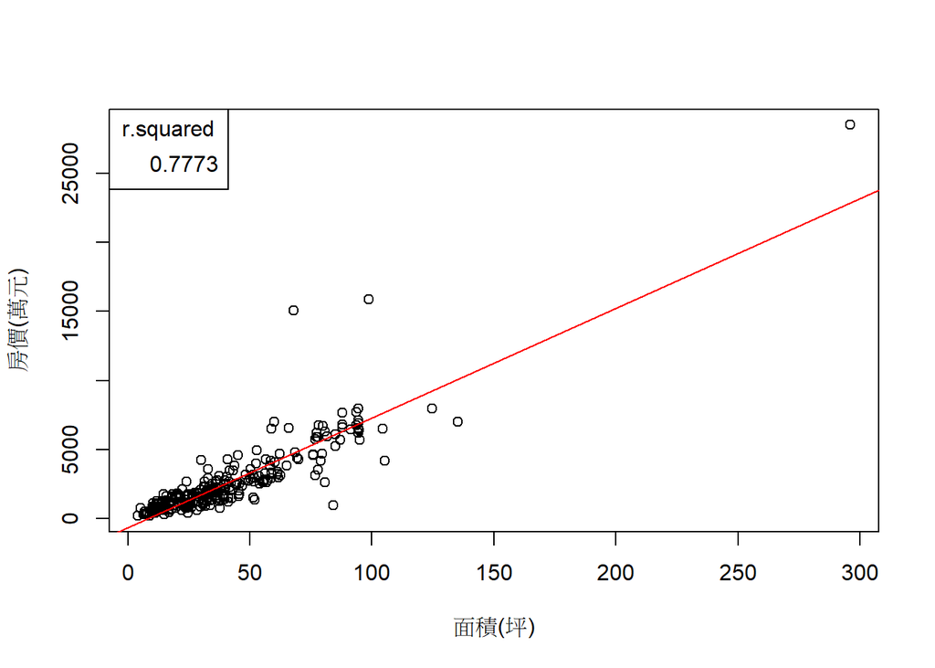

```r
dat3 <- dat1[dat1$縣市=="臺北市",]
x <- dat3$面積坪數
y <- dat3$房價/10^4
plot(x,y,xlab="面積(坪)",ylab="房價(萬元)"); fit<-lm(y~ x)
abline(fit,col=2)
legend("topleft",legend=round(summary(fit)$r.squared,4),title="r.squared")
```

```r
summary(fit)
```

```
##
## Call:
## lm(formula = y ~ x)
##
## Residuals:
##     Min      1Q  Median      3Q     Max
## -5083.1  -581.9   -12.7   453.2 10331.0
##
## Coefficients:
##             Estimate Std. Error t value Pr(>|t|)
## (Intercept) -654.982    130.393  -5.023 9.25e-07 ***
## x             79.401      2.587  30.695  < 2e-16 ***
## ---
## Signif. codes:  0 '***' 0.001 '**' 0.01 '*' 0.05 '.' 0.1 ' ' 1
##
## Residual standard error: 1260 on 270 degrees of freedom
## Multiple R-squared:  0.7773, Adjusted R-squared:  0.7764
## F-statistic: 942.2 on 1 and 270 DF,  p-value: < 2.2e-16
```

### A-1-2.Multiple regression

```r
m12 <- lm(房價~面積坪數+屋齡+型態+車位+管理, data=dat1) #全國的資料
summary(m12)
```

```
##
## Call:
## lm(formula = 房價 ~ 面積坪數 + 屋齡 + 型態 + 車位 + 管理, data = dat1)
##
## Residuals:
##        Min         1Q     Median         3Q        Max
## -192566743   -3607765   -1534917    1352444  234797196
##
## Coefficients:
##              Estimate Std. Error t value Pr(>|t|)
## (Intercept)   1690468     594458   2.844  0.00447 **
## 面積坪數       168120       3383  49.692  < 2e-16 ***
## 屋齡           -22015       9189  -2.396  0.01662 *
## 型態住宅大樓  3168224     524493   6.041 1.63e-09 ***
## 型態店面      9784215     987837   9.905  < 2e-16 ***
## 型態套房       667656     607208   1.100  0.27157
## 型態透天厝    -539015     425985  -1.265  0.20580
## 型態華廈       687209     531469   1.293  0.19605
## 車位無車位   -1720865     321556  -5.352 9.03e-08 ***
## 管理無        1950269     356890   5.465 4.82e-08 ***
## ---
## Signif. codes:  0 '***' 0.001 '**' 0.01 '*' 0.05 '.' 0.1 ' ' 1
##
## Residual standard error: 8623000 on 6160 degrees of freedom
## Multiple R-squared:  0.3723, Adjusted R-squared:  0.3714
## F-statistic: 405.9 on 9 and 6160 DF,  p-value: < 2.2e-16
```

### A-1-3. 比較模型

- 我們採用台北市的資料來建立預測模型
- 以避免因城鄉差距所造成的誤差

```r
dat3 <- dat1[dat1$縣市 %in% "臺北市",] #只挑選台北市的資料集
m22 <- lm(房價~面積坪數+屋齡+型態+車位+管理, data=dat3)
summary(m22)
```

```
##
## Call:
## lm(formula = 房價 ~ 面積坪數 + 屋齡 + 型態 + 車位 + 管理, data = dat3)
##
## Residuals:
##       Min        1Q    Median        3Q       Max
## -52932046  -4094179   -235709   3033508  81857029
##
## Coefficients:
##               Estimate Std. Error t value Pr(>|t|)
## (Intercept)  -21232906    3790063  -5.602 5.35e-08 ***
## 面積坪數        814828      31977  25.482  < 2e-16 ***
## 屋齡            -36199      65208  -0.555  0.57928
## 型態住宅大樓   9323683    2819071   3.307  0.00107 **
## 型態店面      13118402    6810919   1.926  0.05518 .
## 型態套房      12124761    3026383   4.006 8.04e-05 ***
## 型態透天厝    32589133    5715426   5.702 3.19e-08 ***
## 型態華廈       7126678    2788695   2.556  0.01117 *
## 車位無車位     9278302    2060722   4.502 1.01e-05 ***
## 管理無         3203320    1865031   1.718  0.08706 .
## ---
## Signif. codes:  0 '***' 0.001 '**' 0.01 '*' 0.05 '.' 0.1 ' ' 1
##
## Residual standard error: 11230000 on 262 degrees of freedom
## Multiple R-squared:  0.8281, Adjusted R-squared:  0.8222
## F-statistic: 140.3 on 9 and 262 DF,  p-value: < 2.2e-16
```

```r
data.frame("model.taiwan.all"=summary(m12)$r.sq,
           "model.taipei.all"=summary(m22)$r.sq) #比較兩個模型的R-Square
```

```
##   model.taiwan.all model.taipei.all
## 1         0.372274        0.8281325
```

### A-2. 回歸預測模型

- 用台北市的資料，來預測房價
- 所以要將台北市的資料及分成**訓練資料**及**測試資料**

```r
# 先把資料區分成 train=0.8, test=0.2
set.seed(22)
train.index <- sample(x=1:nrow(dat3), size=ceiling(0.8*nrow(dat3) ))

trainingData = dat3[train.index, ]
testData = dat3[-train.index, ]
```

```r
# 使用訓練及資料建置模型 & 使用測試集資料預測結果
mod <- lm(房價~面積坪數+屋齡+型態+車位+管理, data=trainingData, na.action = na.omit)
predictY <- predict(object = mod, newdata = testData)

summary(mod)
```

```
##
## Call:
## lm(formula = 房價 ~ 面積坪數 + 屋齡 + 型態 + 車位 + 管理, data = trainingData,
##     na.action = na.omit)
##
## Residuals:
##       Min        1Q    Median        3Q       Max
## -55551510  -3868591   -412478   3224850  79515464
##
## Coefficients:
##               Estimate Std. Error t value Pr(>|t|)
## (Intercept)  -22899402    4370620  -5.239 3.94e-07 ***
## 面積坪數        837765      35377  23.681  < 2e-16 ***
## 屋齡              2365      80259   0.029 0.976518
## 型態住宅大樓   9967623    3292788   3.027 0.002781 **
## 型態店面      14072189    8704622   1.617 0.107473
## 型態套房      13007305    3563943   3.650 0.000332 ***
## 型態透天厝    30800968    6095477   5.053 9.50e-07 ***
## 型態華廈       8226673    3230887   2.546 0.011612 *
## 車位無車位     9065126    2496275   3.631 0.000355 ***
## 管理無         2805096    2159413   1.299 0.195379
## ---
## Signif. codes:  0 '***' 0.001 '**' 0.01 '*' 0.05 '.' 0.1 ' ' 1
##
## Residual standard error: 11790000 on 208 degrees of freedom
## Multiple R-squared:  0.8359, Adjusted R-squared:  0.8288
## F-statistic: 117.7 on 9 and 208 DF,  p-value: < 2.2e-16
```

```r
#檢視模型預測的效果。
actuals_predicts <- data.frame(cbind(actuals = testData$房價, predicteds = predictY))

#計算真實數據與預測數據的相關係數：越高越好。
cor(actuals_predicts,use="complete.obs")
```

```
##              actuals predicteds
## actuals    1.0000000  0.8778939
## predicteds 0.8778939  1.0000000
```

```r
cor(actuals_predicts,use="pairwise.complete.obs")
```

```
##              actuals predicteds
## actuals    1.0000000  0.8778939
## predicteds 0.8778939  1.0000000
```

```r
#計算AIC, BIC => 越低越好。
AIC(mod)
```

```
## [1] 7729.863
```

```r
BIC(mod)
```

```
## [1] 7767.092
```

```r
#計算模型預測正確率min_max_accuracy
min_max_accuracy <- mean(apply(actuals_predicts, 1, min) / apply(actuals_predicts, 1, max))
min_max_accuracy
```

```
## [1] 0.7029211
```

```r
#計算模型預測錯誤率 MAPE (Mean absolute percentage error)
mape <- mean(abs((actuals_predicts$predicteds - actuals_predicts$actuals))/actuals_predicts$actuals)
mape
```

```
## [1] 0.3860695
```

### 資料來源

- http://whizzalan.github.io/R-tutorial_DataAnalysis/index.html#1